# Demand prediction

Diego de Lima

March 28th, 2019

## Loading the packages

```r
library(data.table)
library(dplyr)
library(stringr)
library(tm)
library(corpus)
library(tidyr)
library(ggplot2)
library(knitr)
```

## Loading the datasets

```r
products <- fread('producto_tabla.csv', encoding = 'UTF-8')
clients <- fread('cliente_tabla.csv', encoding = 'UTF-8')
location <- fread('town_state.csv', encoding = 'UTF-8')
train_set <- fread('train_set2.csv', encoding = 'UTF-8')
```

## Preparing the dataset

Preparing products

```r
kable(head(products))
```

| Producto_ID | NombreProducto |
| --- | --- |
| 0 | NO IDENTIFICADO 0 |
| 9 | Capuccino Moka 750g NES 9 |
| 41 | Bimbollos Ext sAjonjoli 6p 480g BIM 41 |
| 53 | Burritos Sincro 170g CU LON 53 |
| 72 | Div Tira Mini Doradita 4p 45g TR 72 |
| 73 | Pan Multigrano Linaza 540g BIM 73 |

```r
kable(tail(products))
```

| Producto_ID | NombreProducto |
| --- | --- |
| 49990 | Tostado Integral 180g WON 49990 |
| 49992 | Tostado Integral 180g MTA WON 49992 |
| 49993 | Tostado Integral 180g TAB WON 49993 |
| 49994 | Tostado Int 0pct Grasa Azuc 200g WON 49994 |
| 49996 | Tostado Int 0pct Grasa Azuc 200g MTA WON 49996 |
| 49997 | Tostado Int 0pct Grasa Azuc 200g TAB WON 49997 |

Removing the first row from products table

```r
products <- products[-1,]
```

Function to prepare data frame for products

```r
prepare_products <- function(df){
  # Removing the redundancy of the id from the end of the NombreProducto
  df <- df %>% mutate(NombreProducto = gsub('\\d+$', '', NombreProducto))

  # Putting the product name into a new variable
  df <- df %>% mutate(Product = gsub('  ', ' ', gsub(' +$', '', str_extract(NombreProducto, '[^\\d]+'))))

  # Putting the brand into a new variable and removing its spaces
  df <- df %>%
    mutate(Brand = str_extract(NombreProducto, '\\w+ $'))
  df <- df %>% mutate(Brand = gsub(' ', '', Brand))

  # Putting the weight in grams into a new variable
  df <- df %>%
    mutate(
      Weight_grams = str_extract(NombreProducto, '\\d+(?=\\s*g)|\\d+(?=\\s*G)'),
      Weight_kg = str_extract(NombreProducto, '\\d+(?=\\s*Kg)|\\d+(?=\\s*kg)'),
      Weight_grams = if_else(!is.na(Weight_grams), Weight_grams, as.character(as.numeric(Weight_kg) * 1000))
    ) %>%
    select(-Weight_kg)

  # Putting the quantities into a new variable
  df <- df %>%
    mutate(
      Quantity = str_extract(NombreProducto, '\\d+(?=\\s*p)'))

  # Putting the volumes into a new variable
  df <- df %>%
    mutate(
      Volume = str_extract(NombreProducto, '\\d+(?=\\s*ml)|\\d+(?=\\s* ml)'))

  # Removing the stopwords
  df_2 <- df
  df_2 <- df_2 %>% mutate(Product = removeWords(Product, stopwords_es))

  # Subsetting the dataset
  df_3 <- df_2[, c(1,3)]
  # Combining into product names
  df<- df_2[-2] %>%
    mutate(
      Product = paste(Product, ' ', Brand, sep = ''),
      Product = if_else(!is.na(Weight_grams), paste(Product,' ', Weight_grams, 'g', sep = ''), Product),
      Product = if_else(!is.na(Quantity), paste(Product,' ', Quantity, 'p', sep = ''), Product),
      Product = if_else(!is.na(Volume), paste(Product,' ', Volume, 'ml', sep = ''), Product)) %>%
    select(Producto_ID, Product)

  return(df)
}
```

Calling the function to prepare the products data frame

```r
products <- prepare_products(products)
kable(head(products))
```

| Producto_ID | Product |
| --- | --- |
| 9 | Capuccino Moka NES 750g |
| 41 | Bimbollos Ext sAjonjoli BIM 480g 6p |
| 53 | Burritos Sincro LON 170g |
| 72 | Div Tira Mini Doradita TR 45g 4p |
| 73 | Pan Multigrano Linaza BIM 540g |
| 98 | Tostado Integral WON 180g |

Updating the train_set

```r
train_set <- merge(products, train_set, by = 'Producto_ID')
kable(head(train_set))
```

| Producto_ID | Product | Semana | Agencia_ID | Canal_ID | Ruta_SAK | Cliente_ID | Venta_uni_hoy | Venta_hoy | Dev_uni_proxima | Dev_proxima | Demanda_uni_equil |
| --- | --- | --- | --- | --- | --- | --- | --- | --- | --- | --- | --- |
| 41 | Bimbollos Ext sAjonjoli BIM 480g 6p | 3 | 23879 | 7 | 3201 | 1546790 | 200 | 3626.0 | 0 | 0.0 | 200 |
| 41 | Bimbollos Ext sAjonjoli BIM 480g 6p | 7 | 2281 | 7 | 3306 | 681747 | 1570 | 28464.1 | 0 | 0.0 | 1570 |
| 41 | Bimbollos Ext sAjonjoli BIM 480g 6p | 6 | 2281 | 7 | 3306 | 681747 | 1250 | 22662.5 | 0 | 0.0 | 1250 |
| 41 | Bimbollos Ext sAjonjoli BIM 480g 6p | 8 | 2281 | 7 | 3306 | 465617 | 30 | 543.9 | 70 | 1269.1 | 0 |
| 53 | Burritos Sincro LON 170g | 9 | 1452 | 4 | 1008 | 2502084 | 912 | 13041.6 | 0 | 0.0 | 912 |
| 53 | Burritos Sincro LON 170g | 9 | 1374 | 4 | 6652 | 4578089 | 2 | 28.6 | 0 | 0.0 | 2 |

## Preparing clients

Removing duplicate data

```r
clients <- distinct(clients, Cliente_ID, .keep_all = T)
```

Removing excedent spaces

```r
clients <- clients %>% mutate(NombreCliente = gsub('  ', '', NombreCliente))
kable(head(clients))
```

| Cliente_ID | NombreCliente |
| --- | --- |
| 0 | SIN NOMBRE |
| 1 | OXXO XINANTECATL |
| 2 | SIN NOMBRE |
| 3 | EL MORENO |
| 4 | SDN SERDE ALIMCUERPO SA CIADE INT |
| 5 | LA VAQUITA |

```r
train_set <- merge(clients, train_set, by = 'Cliente_ID')
kable(head(train_set))
```

| Cliente_ID | NombreCliente | Producto_ID | Product | Semana | Agencia_ID | Canal_ID | Ruta_SAK | Venta_uni_hoy | Venta_hoy | Dev_uni_proxima | Dev_proxima | Demanda_uni_equil |
| --- | --- | --- | --- | --- | --- | --- | --- | --- | --- | --- | --- | --- |
| 26 | BODEGA COMERCIAL MEXICANA TOLUCA | 43039 | Cuernitos TR 100g | 9 | 2061 | 2 | 7212 | 15 | 138.00 | 15 | 138 | 0 |
| 26 | BODEGA COMERCIAL MEXICANA TOLUCA | 34204 | Bimbollos BIM 450g 8p | 4 | 2061 | 2 | 7212 | 30 | 590.40 | 0 | 0 | 30 |
| 26 | BODEGA COMERCIAL MEXICANA TOLUCA | 43343 | DonitasEspolvoreadas ME BIM 210g 12p | 7 | 2061 | 2 | 7212 | 7 | 101.64 | 0 | 0 | 7 |
| 26 | BODEGA COMERCIAL MEXICANA TOLUCA | 48021 | Lata Butter Danesas GBI 400g | 7 | 2655 | 2 | 3076 | 12 | 480.72 | 0 | 0 | 12 |
| 26 | BODEGA COMERCIAL MEXICANA TOLUCA | 43060 | Bimbolunch BIM 354g 6p | 7 | 2061 | 2 | 7212 | 6 | 120.00 | 0 | 0 | 6 |
| 26 | BODEGA COMERCIAL MEXICANA TOLUCA | 35145 | Wonder WON 567g 100p | 7 | 2061 | 2 | 7212 | 40 | 852.80 | 0 | 0 | 40 |

## Preparing Location

Removing State

```r
location <- location[, 1:2]
kable(head(location))
```

| Agencia_ID | Town |
| --- | --- |
| 1110 | 2008 AG. LAGO FILT |
| 1111 | 2002 AG. AZCAPOTZALCO |
| 1112 | 2004 AG. CUAUTITLAN |
| 1113 | 2008 AG. LAGO FILT |
| 1114 | 2029 AG.IZTAPALAPA 2 |
| 1116 | 2011 AG. SAN ANTONIO |

```r
train_set <- merge(location, train_set, by = 'Agencia_ID')
kable(head(train_set))
```

| Agencia_ID | Town | Cliente_ID | NombreCliente | Producto_ID | Product | Semana | Canal_ID | Ruta_SAK | Venta_uni_hoy | Venta_hoy | Dev_uni_proxima | Dev_proxima | Demanda_uni_equil |
| --- | --- | --- | --- | --- | --- | --- | --- | --- | --- | --- | --- | --- | --- |
| 1110 | 2008 AG. LAGO FILT | 15766 | PUESTO DE PERIODICOS LAZARO | 31309 | Canelitas MLA 90g | 7 | 7 | 3301 | 7 | 43.75 | 0 | 0 | 7 |
| 1110 | 2008 AG. LAGO FILT | 15766 | PUESTO DE PERIODICOS LAZARO | 32819 | Chocodonitas BIM 102g 6p | 5 | 7 | 3301 | 2 | 17.78 | 0 | 0 | 2 |
| 1110 | 2008 AG. LAGO FILT | 15766 | PUESTO DE PERIODICOS LAZARO | 1220 | Colchones BIM 130g 6p | 8 | 7 | 3301 | 1 | 7.64 | 0 | 0 | 1 |
| 1110 | 2008 AG. LAGO FILT | 15766 | PUESTO DE PERIODICOS LAZARO | 32819 | Chocodonitas BIM 102g 6p | 4 | 7 | 3301 | 1 | 8.89 | 0 | 0 | 1 |
| 1110 | 2008 AG. LAGO FILT | 15766 | PUESTO DE PERIODICOS LAZARO | 35651 | Madalenas BIM 93g 3p | 5 | 7 | 3301 | 3 | 22.50 | 0 | 0 | 3 |
| 1110 | 2008 AG. LAGO FILT | 16119 | HOSPITAL ALVARO OBREGON | 1125 | Tortillinas TR 255g 10p | 8 | 7 | 3311 | 32 | 307.20 | 0 | 0 | 32 |

Checking if there are different channels for the same Town

```r
kable(head(table(data.frame(Channel_Location = paste(train_set$Town, train_set$Canal_ID))[, 1]), 50), caption = '50 first results')
```

50 first results

| Var1 | Freq |
| --- | --- |
| 2001 AG. ATIZAPAN 1 | 50526 |
| 2001 AG. ATIZAPAN 4 | 1889 |
| 2002 AG. AZCAPOTZALCO 1 | 30358 |
| 2002 AG. AZCAPOTZALCO 4 | 1713 |
| 2003 AG. COACALCO 1 | 32138 |
| 2003 AG. COACALCO 4 | 3394 |
| 2004 AG. CUAUTITLAN 1 | 23978 |
| 2004 AG. CUAUTITLAN 4 | 2002 |
| 2007 AG. LA VILLA 1 | 43358 |
| 2008 AG. LAGO FILT 1 | 13873 |
| 2008 AG. LAGO FILT 11 | 297 |
| 2008 AG. LAGO FILT 4 | 4710 |
| 2008 AG. LAGO FILT 7 | 3212 |
| 2008 AG. LAGO FILT 8 | 210 |
| 2010 AG. LOS REYES 1 | 31227 |
| 2010 AG. LOS REYES 6 | 482 |
| 2010 AG. LOS REYES 7 | 1460 |
| 2010 AG. LOS REYES 8 | 43 |
| 2011 AG. SAN ANTONIO 1 | 33076 |
| 2011 AG. SAN ANTONIO 11 | 354 |
| 2011 AG. SAN ANTONIO 2 | 3418 |
| 2011 AG. SAN ANTONIO 4 | 8734 |
| 2011 AG. SAN ANTONIO 6 | 1923 |
| 2011 AG. SAN ANTONIO 7 | 4583 |
| 2011 AG. SAN ANTONIO 8 | 363 |
| 2013 AG. MEGA NAUCALPAN 1 | 47814 |
| 2013 AG. MEGA NAUCALPAN 11 | 275 |
| 2013 AG. MEGA NAUCALPAN 2 | 3311 |
| 2013 AG. MEGA NAUCALPAN 5 | 573 |
| 2013 AG. MEGA NAUCALPAN 6 | 481 |
| 2013 AG. MEGA NAUCALPAN 7 | 2118 |
| 2013 AG. MEGA NAUCALPAN 8 | 80 |
| 2014 AG. NEZA 1 | 30350 |
| 2015 AG. ROJO GOMEZ 1 | 23726 |
| 2016 AG. SAN LORENZO 1 | 36109 |
| 2017 AG. SANTA CLARA 1 | 61188 |
| 2018 AG. TEPALCATES 2 1 | 31402 |
| 2018 AG. TEPALCATES 2 4 | 2887 |
| 2019 AG. XALOSTOC 1 | 49738 |
| 2019 AG. XALOSTOC 4 | 1151 |
| 2021 AG. XOCHIMILCO 2 1 | 26883 |
| 2027 AG. VALLEJO 1 | 26534 |
| 2027 AG. VALLEJO 11 | 296 |
| 2027 AG. VALLEJO 7 | 3557 |
| 2027 AG. VALLEJO 8 | 213 |
| 2029 AG.IZTAPALAPA 2 1 | 17991 |
| 2029 AG.IZTAPALAPA 2 11 | 196 |
| 2029 AG.IZTAPALAPA 2 2 | 3261 |
| 2029 AG.IZTAPALAPA 2 5 | 292 |
| 2029 AG.IZTAPALAPA 2 6 | 508 |

**Since there are different channels for the same Town, there’s a possibility of some channel be sending more product than expected.**

Checking the returned units by channel

```r
return_by_channel <- distinct(train_set %>% group_by(Canal_ID) %>% mutate(Returns = sum(Dev_uni_proxima)) %>% select(Canal_ID, Returns), Canal_ID, .keep_all = T)
return_by_channel <- data.frame(return_by_channel[order(-return_by_channel$Returns), ])
return_by_channel <- return_by_channel %>% mutate(
  Cum_Return = cumsum(Returns),
  Perc = round((Returns / sum(Returns)) * 100 , 2),
  Cum_Perc = round((Cum_Return / sum(Returns)) * 100 , 2)
)
kable(return_by_channel)
```

| Canal_ID | Returns | Cum_Return | Perc | Cum_Perc |
| --- | --- | --- | --- | --- |
| 1 | 414160 | 414160 | 47.07 | 47.07 |
| 5 | 322734 | 736894 | 36.68 | 83.75 |
| 2 | 84333 | 821227 | 9.58 | 93.33 |
| 4 | 18381 | 839608 | 2.09 | 95.42 |
| 11 | 15983 | 855591 | 1.82 | 97.23 |
| 8 | 10484 | 866075 | 1.19 | 98.43 |
| 7 | 9887 | 875962 | 1.12 | 99.55 |
| 6 | 3961 | 879923 | 0.45 | 100.00 |
| 9 | 0 | 879923 | 0.00 | 100.00 |

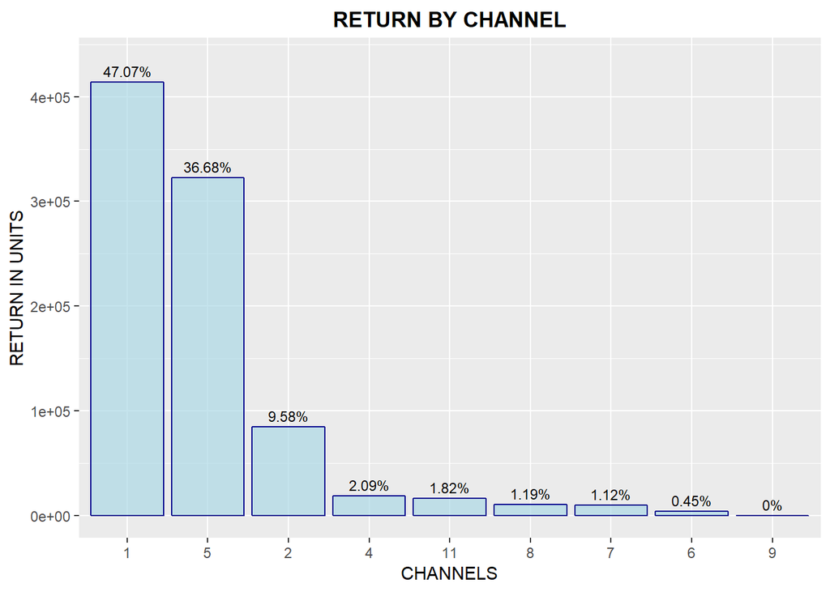

```r
ggplot(return_by_channel,
       aes(x = reorder(Canal_ID, -Returns), y = Returns)) +
  geom_col(fill = 'lightblue', color = 'darkblue', alpha = 0.7) +
  geom_text(aes(label = paste(Perc, '%', sep = '')), vjust = -0.5, size = 3) +
  ggtitle('RETURN BY CHANNEL') +
  xlab('CHANNELS') +
  ylab('RETURN IN UNITS') +
  ylim(0, max(return_by_channel$Returns) * 1.05) +
  theme(plot.title = element_text(hjust = 0.5, vjust = 0.5, face = 'bold'),
        axis.text.x = element_text(hjust = 0.5))
```

**As checked on the plot, the channels 1 and 5 have more than 80% of the returns.** **Since constraints by channel have not been informed, at this point it will be suggested to integrate the total of demand to all channels by sharing the total of sells.** **So, channel will not be considered in the following analyses.** **The route will also not be considered, since it’s to do to the strategy of transportation.**

Converting train_set into data.frame

```r
train_set <- data.frame(train_set)
kable(head(train_set))
```

| Agencia_ID | Town | Cliente_ID | NombreCliente | Producto_ID | Product | Semana | Canal_ID | Ruta_SAK | Venta_uni_hoy | Venta_hoy | Dev_uni_proxima | Dev_proxima | Demanda_uni_equil |
| --- | --- | --- | --- | --- | --- | --- | --- | --- | --- | --- | --- | --- | --- |
| 1110 | 2008 AG. LAGO FILT | 15766 | PUESTO DE PERIODICOS LAZARO | 31309 | Canelitas MLA 90g | 7 | 7 | 3301 | 7 | 43.75 | 0 | 0 | 7 |
| 1110 | 2008 AG. LAGO FILT | 15766 | PUESTO DE PERIODICOS LAZARO | 32819 | Chocodonitas BIM 102g 6p | 5 | 7 | 3301 | 2 | 17.78 | 0 | 0 | 2 |
| 1110 | 2008 AG. LAGO FILT | 15766 | PUESTO DE PERIODICOS LAZARO | 1220 | Colchones BIM 130g 6p | 8 | 7 | 3301 | 1 | 7.64 | 0 | 0 | 1 |
| 1110 | 2008 AG. LAGO FILT | 15766 | PUESTO DE PERIODICOS LAZARO | 32819 | Chocodonitas BIM 102g 6p | 4 | 7 | 3301 | 1 | 8.89 | 0 | 0 | 1 |
| 1110 | 2008 AG. LAGO FILT | 15766 | PUESTO DE PERIODICOS LAZARO | 35651 | Madalenas BIM 93g 3p | 5 | 7 | 3301 | 3 | 22.50 | 0 | 0 | 3 |
| 1110 | 2008 AG. LAGO FILT | 16119 | HOSPITAL ALVARO OBREGON | 1125 | Tortillinas TR 255g 10p | 8 | 7 | 3311 | 32 | 307.20 | 0 | 0 | 32 |

Checking the variables type

```r
str(train_set)
```

```
## 'data.frame':    5000000 obs. of  14 variables:
##  $ Agencia_ID       : int  1110 1110 1110 1110 1110 1110 1110 1110 1110 1110 ...
##  $ Town             : chr  "2008 AG. LAGO FILT" "2008 AG. LAGO FILT" "2008 AG. LAGO FILT" "2008 AG. LAGO FILT" ...
##  $ Cliente_ID       : int  15766 15766 15766 15766 15766 16119 16119 16119 16119 16127 ...
##  $ NombreCliente    : chr  "PUESTO DE PERIODICOS LAZARO" "PUESTO DE PERIODICOS LAZARO" "PUESTO DE PERIODICOS LAZARO" "PUESTO DE PERIODICOS LAZARO" ...
##  $ Producto_ID      : int  31309 32819 1220 32819 35651 1125 2233 2233 1182 1250 ...
##  $ Product          : chr  "Canelitas MLA 90g" "Chocodonitas BIM 102g 6p" "Colchones BIM 130g 6p" "Chocodonitas BIM 102g 6p" ...
##  $ Semana           : int  7 5 8 4 5 8 8 5 6 6 ...
##  $ Canal_ID         : int  7 7 7 7 7 7 7 7 7 7 ...
##  $ Ruta_SAK         : int  3301 3301 3301 3301 3301 3311 3311 3311 3311 3314 ...
##  $ Venta_uni_hoy    : int  7 2 1 1 3 32 31 16 13 5 ...
##  $ Venta_hoy        : num  43.75 17.78 7.64 8.89 22.5 ...
##  $ Dev_uni_proxima  : int  0 0 0 0 0 0 0 0 0 0 ...
##  $ Dev_proxima      : num  0 0 0 0 0 0 0 0 0 0 ...
##  $ Demanda_uni_equil: int  7 2 1 1 3 32 31 16 13 5 ...
```

**The IDs (Agencia, Cliente and Producto) could be categoric variables. But, to guarantee that possible future data won’t be duplicated by using different IDs, it will be considered to use the description for each one:** **Town for Agencia_ID, NombreCliente for Cliente_ID, Product for Producto_ID.**

## Products Analysis

```r
products_analysis <- train_set[,c(6, 10:14)]
products_analysis <- distinct(products_analysis %>%
                                group_by(Product) %>%
                                mutate(
                                  Venta_uni_hoy = sum(Venta_uni_hoy),
                                  Venta_hoy = sum(Venta_hoy),
                                  Dev_uni_proxima = sum(Dev_uni_proxima),
                                  Dev_proxima = sum(Dev_proxima),
                                  Demanda_uni_equil = sum(Demanda_uni_equil)
                                ), Product, .keep_all = T)
```

Checking the number of products

```r
length(unique(products_analysis$Product))
```

```
## [1] 815
```

**Since the number of products reaches to 815, it’s considered too much to address throught.** **So, the Pareto’s Theorem will be considered to sub set the products that represent 80% of the total of Demand, Return in units or Return in pesos.** **To choose the best strategy will be chosen the dataset with the lowest number of products and the highest potential to reduce the number of returns.**

Demand by product

```r
demand_by_product <- data.frame(products_analysis[order(-products_analysis$Demanda_uni_equil),][,c(1, 6)])
demand_by_product <- demand_by_product %>% mutate(
  Cum_Demand = cumsum(Demanda_uni_equil),
  Perc = round((Demanda_uni_equil / sum(Demanda_uni_equil)) * 100 , 2),
  Cum_Perc = round((Cum_Demand / sum(Demanda_uni_equil)) * 100 , 2)
)
```

Table of the products which correspond 80% of the total of the demand

```r
kable(demand_by_product %>% filter(Cum_Perc <= 80))
```

| Product | Demanda_uni_equil | Cum_Demand | Perc | Cum_Perc |
| --- | --- | --- | --- | --- |
| Nito BIM 62g 1p | 3863539 | 3863539 | 10.69 | 10.69 |
| Rebanada BIM 55g 2p | 1736958 | 5600497 | 4.80 | 15.49 |
| Gansito MLA 50g 1p | 1624963 | 7225460 | 4.49 | 19.99 |
| Mantecadas Vainilla BIM 125g 4p | 941350 | 8166810 | 2.60 | 22.59 |
| Donas Azucar BIM 105g 4p | 901299 | 9068109 | 2.49 | 25.08 |
| Pan Blanco BIM 640g | 880477 | 9948586 | 2.44 | 27.52 |
| Donitas Espolvoreadas BIM 105g 6p | 865512 | 10814098 | 2.39 | 29.91 |
| Bolsa Mini Rocko MLA 13g 40p | 862571 | 11676669 | 2.39 | 32.30 |
| Polvoroncitos Panera TR 25g 40p | 815333 | 12492002 | 2.26 | 34.55 |
| Madalenas BIM 93g 3p | 779588 | 13271590 | 2.16 | 36.71 |
| Medias Noches BIM 340g 8p | 704226 | 13975816 | 1.95 | 38.66 |
| Principe MLA 106g 10p | 645731 | 14621547 | 1.79 | 40.44 |
| Choco Roles MLA 80g 2p | 644951 | 15266498 | 1.78 | 42.23 |
| Barritas Fresa MLA 67g | 625802 | 15892300 | 1.73 | 43.96 |
| Pinguinos MLA 80g 2p | 610216 | 16502516 | 1.69 | 45.65 |
| Tortillinas TR 255g 10p | 601499 | 17104015 | 1.66 | 47.31 |
| Pan Integral BIM 675g | 524218 | 17628233 | 1.45 | 48.76 |
| Pan Molido BIM 210g | 430737 | 18058970 | 1.19 | 49.95 |
| Mantecadas Nuez BIM 123g | 386264 | 18445234 | 1.07 | 51.02 |
| Bimbunuelos BIM 66g 4p | 378418 | 18823652 | 1.05 | 52.07 |
| Barritas Fresa MLA 75g | 374285 | 19197937 | 1.04 | 53.10 |
| Panque Nuez BIM 255g | 359127 | 19557064 | 0.99 | 54.09 |
| Tostado BIM 210g | 345147 | 19902211 | 0.95 | 55.05 |
| Sponch MLA 120g 8p | 342377 | 20244588 | 0.95 | 56.00 |
| Pan Blanco Chico BIM 360g | 341715 | 20586303 | 0.95 | 56.94 |
| Barritas Pina MLA 67g | 324762 | 20911065 | 0.90 | 57.84 |
| Pan Integral BIM 680g | 306540 | 21217605 | 0.85 | 58.69 |
| Pan Blanco BIM 680g | 298690 | 21516295 | 0.83 | 59.51 |
| Doraditas TR 110g | 293259 | 21809554 | 0.81 | 60.32 |
| Bran Frut Fresa BIM 48g | 292328 | 22101882 | 0.81 | 61.13 |
| Roles Glass BIM 135g 2p | 291065 | 22392947 | 0.81 | 61.94 |
| Panquecito Gota Choc BIM 140g 2p | 288403 | 22681350 | 0.80 | 62.74 |
| Tortillinas TR 310g 12p | 279053 | 22960403 | 0.77 | 63.51 |
| Roles Canela BIM 120g 2p | 270933 | 23231336 | 0.75 | 64.26 |
| Canelitas MLA 90g | 265961 | 23497297 | 0.74 | 64.99 |
| Polvoron MLA 113g 6p | 243254 | 23740551 | 0.67 | 65.67 |
| Bimbollos BIM 450g 8p | 241561 | 23982112 | 0.67 | 66.33 |
| Dalmata MLA 55g 1p | 238372 | 24220484 | 0.66 | 66.99 |
| Wonder WON 567g 100p | 221564 | 24442048 | 0.61 | 67.61 |
| Tortillinas TR 510g 20p | 204432 | 24646480 | 0.57 | 68.17 |
| Colchones BIM 130g 6p | 197783 | 24844263 | 0.55 | 68.72 |
| Pan Blanco BIM 460g | 194511 | 25038774 | 0.54 | 69.26 |
| Triki Trakes MLA 69g 8p | 190522 | 25229296 | 0.53 | 69.78 |
| Barritas Pina MLA 75g | 171534 | 25400830 | 0.47 | 70.26 |
| Chocotorro Fresa MLA 50g 1p | 170721 | 25571551 | 0.47 | 70.73 |
| Totopos DH 280g | 169615 | 25741166 | 0.47 | 71.20 |
| Pan Integral BIM 370g | 169240 | 25910406 | 0.47 | 71.67 |
| Leche Nito BIM 236ml | 168609 | 26079015 | 0.47 | 72.13 |
| Tortillinas TR 570g 22p | 162960 | 26241975 | 0.45 | 72.58 |
| Bimbollos Extra BIM 480g 6p | 155959 | 26397934 | 0.43 | 73.02 |
| Pan Integral BIM 480g | 155650 | 26553584 | 0.43 | 73.45 |
| Mantecadas TR 105g 2p | 147298 | 26700882 | 0.41 | 73.85 |
| Super Pan Blanco BIM 740g | 146265 | 26847147 | 0.40 | 74.26 |
| Tostada Ondulada Tubo MR 360g 30p | 142726 | 26989873 | 0.39 | 74.65 |
| Cuernitos TR 100g | 141597 | 27131470 | 0.39 | 75.04 |
| Submarinos Fresa MLA 105g 3p | 140805 | 27272275 | 0.39 | 75.43 |
| Pan Multigrano Linaza BIM 540g | 133309 | 27405584 | 0.37 | 75.80 |
| Mantecada Vainilla TR 157g 3p | 129336 | 27534920 | 0.36 | 76.16 |
| Napolitano MLA 70g 1p | 128060 | 27662980 | 0.35 | 76.51 |
| Empanizador Crujiente BIM 175g | 126912 | 27789892 | 0.35 | 76.87 |
| Bigotes Chocolate TR 60g | 126872 | 27916764 | 0.35 | 77.22 |
| Conchas Vainilla BIM 120g 2p | 125769 | 28042533 | 0.35 | 77.56 |
| Rebanada Sandwich MP BIM 55g 2p | 124195 | 28166728 | 0.34 | 77.91 |
| Gansito MLA 50g | 122845 | 28289573 | 0.34 | 78.25 |
| Submarinos Vainilla MLA 105g 3p | 120866 | 28410439 | 0.33 | 78.58 |
| Roles Canela BIM 365g 6p | 116130 | 28526569 | 0.32 | 78.90 |
| Canelitas MLA 120g | 114300 | 28640869 | 0.32 | 79.22 |
| Rocko Tira MLA 44g 10p | 111230 | 28752099 | 0.31 | 79.53 |
| Tostado Doble Fibra BIM 250g | 111218 | 28863317 | 0.31 | 79.83 |

Return by product

```r
return_by_product <- data.frame(products_analysis[order(-products_analysis$Dev_uni_proxima),][,c(1, 4)])
return_by_product <- return_by_product %>% mutate(
  Cum_Dev = cumsum(Dev_uni_proxima),
  Perc = round((Dev_uni_proxima / sum(Dev_uni_proxima)) * 100 , 2),
  Cum_Perc = round((Cum_Dev / sum(Dev_uni_proxima)) * 100 , 2)
)
```

Table of the products which correspond 80% of the total of the total of returns in units

```r
kable(return_by_product %>% filter(Cum_Perc <= 80))
```

| Product | Dev_uni_proxima | Cum_Dev | Perc | Cum_Perc |
| --- | --- | --- | --- | --- |
| Paletina Cafe NES NES | 250000 | 250000 | 28.41 | 28.41 |
| Nito BIM 62g 1p | 34481 | 284481 | 3.92 | 32.33 |
| Bolsa Mini Rocko MLA 13g 40p | 18925 | 303406 | 2.15 | 34.48 |
| Madalenas BIM 93g 3p | 18620 | 322026 | 2.12 | 36.60 |
| Choco Roles MLA 80g 2p | 17049 | 339075 | 1.94 | 38.53 |
| Donas Azucar BIM 105g 4p | 16070 | 355145 | 1.83 | 40.36 |
| Mantecadas Vainilla BIM 125g 4p | 15704 | 370849 | 1.78 | 42.15 |
| Gansito MLA 50g 1p | 14677 | 385526 | 1.67 | 43.81 |
| Tortillinas TR 255g 10p | 14226 | 399752 | 1.62 | 45.43 |
| Pan Blanco BIM 640g | 12216 | 411968 | 1.39 | 46.82 |
| Barritas Fresa MLA 67g | 12122 | 424090 | 1.38 | 48.20 |
| Tostado BIM 210g | 10986 | 435076 | 1.25 | 49.44 |
| Rebanada BIM 55g 2p | 10682 | 445758 | 1.21 | 50.66 |
| Medias Noches BIM 340g 8p | 9370 | 455128 | 1.06 | 51.72 |
| Donitas Espolvoreadas BIM 105g 6p | 8884 | 464012 | 1.01 | 52.73 |
| Mantecadas Nuez BIM 123g | 8729 | 472741 | 0.99 | 53.73 |
| Panque Nuez BIM 255g | 8456 | 481197 | 0.96 | 54.69 |
| Barritas Pina MLA 67g | 7934 | 489131 | 0.90 | 55.59 |
| Polvoroncitos Panera TR 25g 40p | 7690 | 496821 | 0.87 | 56.46 |
| Roles Canela BIM 120g 2p | 7127 | 503948 | 0.81 | 57.27 |
| Pinguinos MLA 80g 2p | 7055 | 511003 | 0.80 | 58.07 |
| Panquecito Gota Choc BIM 140g 2p | 6717 | 517720 | 0.76 | 58.84 |
| Cuernito Jamon Queso LT LON 80g | 6325 | 524045 | 0.72 | 59.56 |
| Roles Glass BIM 135g 2p | 6304 | 530349 | 0.72 | 60.27 |
| Pan Molido BIM 210g | 5778 | 536127 | 0.66 | 60.93 |
| Bimbollos BIM 450g 8p | 5709 | 541836 | 0.65 | 61.58 |
| Pan Integral BIM 675g | 5604 | 547440 | 0.64 | 62.21 |
| Bran Frut Fresa BIM 48g | 5500 | 552940 | 0.63 | 62.84 |
| Pan Blanco Chico BIM 360g | 5475 | 558415 | 0.62 | 63.46 |
| Bimbunuelos BIM 66g 4p | 5463 | 563878 | 0.62 | 64.08 |
| Doraditas TR 110g | 5459 | 569337 | 0.62 | 64.70 |
| Panque Pasas BIM 255g | 5062 | 574399 | 0.58 | 65.28 |
| Mantecadas TR 105g 2p | 4933 | 579332 | 0.56 | 65.84 |
| Pan Blanco BIM 680g | 4866 | 584198 | 0.55 | 66.39 |
| Cuernitos TR 100g | 4804 | 589002 | 0.55 | 66.94 |
| Bigotes Chocolate TR 60g | 4636 | 593638 | 0.53 | 67.46 |
| Conchas TR 180g 3p | 4501 | 598139 | 0.51 | 67.98 |
| Principe MLA 106g 10p | 4297 | 602436 | 0.49 | 68.46 |
| Triki Intenso MLA 80g | 4272 | 606708 | 0.49 | 68.95 |
| Conchas TR 120g 2p | 4181 | 610889 | 0.48 | 69.43 |
| Canelitas MLA 90g | 4007 | 614896 | 0.46 | 69.88 |
| Tortillinas TR 510g 20p | 3984 | 618880 | 0.45 | 70.33 |
| Pan Integral BIM 680g | 3920 | 622800 | 0.45 | 70.78 |
| Pan Integral BIM 370g | 3713 | 626513 | 0.42 | 71.20 |
| Roles Canela BIM 365g 6p | 3614 | 630127 | 0.41 | 71.61 |
| Panque Marmol BIM 255g | 3547 | 633674 | 0.40 | 72.01 |
| Conchas Vainilla BIM 120g 2p | 3531 | 637205 | 0.40 | 72.42 |
| Mantecada Vainilla TR 157g 3p | 3465 | 640670 | 0.39 | 72.81 |
| Pan Multigrano BIM 540g | 3442 | 644112 | 0.39 | 73.20 |
| Colchones BIM 130g 6p | 3130 | 647242 | 0.36 | 73.56 |
| Bimbunuelos Canela BIM 33g 2p | 3112 | 650354 | 0.35 | 73.91 |
| Coca Cola Lata CC 355ml | 3094 | 653448 | 0.35 | 74.26 |
| Dalmata MLA 55g 1p | 3083 | 656531 | 0.35 | 74.61 |
| Barritas Fresa MLA 75g | 3074 | 659605 | 0.35 | 74.96 |
| Chocotorro Fresa MLA 50g 1p | 3035 | 662640 | 0.34 | 75.31 |
| Wonder WON 567g 100p | 3025 | 665665 | 0.34 | 75.65 |
| Bimbollos Extra BIM 480g 6p | 2988 | 668653 | 0.34 | 75.99 |
| Cuernitos Famili Pack TR 150g 3p | 2952 | 671605 | 0.34 | 76.33 |
| Bran Frut Pina BIM 48g | 2897 | 674502 | 0.33 | 76.65 |
| Submarinos Vainilla MLA 105g 3p | 2872 | 677374 | 0.33 | 76.98 |
| Submarinos Fresa MLA 105g 3p | 2855 | 680229 | 0.32 | 77.31 |
| Rocko Tira MLA 44g 10p | 2839 | 683068 | 0.32 | 77.63 |
| Pan Multigrano Linaza BIM 540g | 2664 | 685732 | 0.30 | 77.93 |
| Pan Doble Fibra BIM 640g | 2612 | 688344 | 0.30 | 78.23 |
| Tostada Ondulada Tubo MR 360g 30p | 2571 | 690915 | 0.29 | 78.52 |
| Kiyakis BAR 50g 25p | 2546 | 693461 | 0.29 | 78.81 |
| Pan Blanco BIM 460g | 2496 | 695957 | 0.28 | 79.09 |
| Barra Multigrano Nuez BIM 34g | 2467 | 698424 | 0.28 | 79.37 |
| Duo Nito BIM 124g | 2439 | 700863 | 0.28 | 79.65 |
| Pay Pina MLA 85g 1p | 2414 | 703277 | 0.27 | 79.92 |

Cost of return by product

```r
cost_by_product <- data.frame(products_analysis[order(-products_analysis$Dev_proxima),][,c(1, 5)])
cost_by_product <- cost_by_product %>% mutate(
  Cum_Dev = cumsum(Dev_proxima),
  Perc = round((Dev_proxima / sum(Dev_proxima)) * 100 , 2),
  Cum_Perc = round((Cum_Dev / sum(Dev_proxima)) * 100 , 2)
)
```

Table of the products which correpond 80% of the total of the costs with return

```r
kable(cost_by_product %>% filter(Cum_Perc <= 80))
```

| Product | Dev_proxima | Cum_Dev | Perc | Cum_Perc |
| --- | --- | --- | --- | --- |
| Pan Blanco BIM 640g | 243990.13 | 243990.1 | 3.91 | 3.91 |
| Nito BIM 62g 1p | 158681.20 | 402671.3 | 2.54 | 6.45 |
| Panque Nuez BIM 255g | 154913.58 | 557584.9 | 2.48 | 8.94 |
| Tostado BIM 210g | 153357.94 | 710942.8 | 2.46 | 11.39 |
| Mantecadas Vainilla BIM 125g 4p | 144397.85 | 855340.7 | 2.31 | 13.71 |
| Madalenas BIM 93g 3p | 140618.00 | 995958.7 | 2.25 | 15.96 |
| Tortillinas TR 255g 10p | 136868.00 | 1132826.7 | 2.19 | 18.15 |
| Medias Noches BIM 340g 8p | 132308.58 | 1265135.3 | 2.12 | 20.27 |
| Choco Roles MLA 80g 2p | 132247.78 | 1397383.1 | 2.12 | 22.39 |
| Donas Azucar BIM 105g 4p | 130034.01 | 1527417.1 | 2.08 | 24.48 |
| Pan Integral BIM 675g | 120229.54 | 1647646.6 | 1.93 | 26.40 |
| Bimbollos BIM 450g 8p | 108160.45 | 1755807.1 | 1.73 | 28.14 |
| Pan Blanco BIM 680g | 101944.39 | 1857751.4 | 1.63 | 29.77 |
| Pan Integral BIM 680g | 88158.16 | 1945909.6 | 1.41 | 31.18 |
| Mantecadas Nuez BIM 123g | 86798.79 | 2032708.4 | 1.39 | 32.58 |
| Panque Pasas BIM 255g | 84733.05 | 2117441.5 | 1.36 | 33.93 |
| Pan Blanco Chico BIM 360g | 82310.09 | 2199751.5 | 1.32 | 35.25 |
| Barritas Fresa MLA 67g | 79714.46 | 2279466.0 | 1.28 | 36.53 |
| Gansito MLA 50g 1p | 77335.08 | 2356801.1 | 1.24 | 37.77 |
| Pan Multigrano BIM 540g | 74556.64 | 2431357.7 | 1.19 | 38.96 |
| Tortillinas TR 510g 20p | 69999.20 | 2501356.9 | 1.12 | 40.09 |
| Donitas Espolvoreadas BIM 105g 6p | 68827.24 | 2570184.2 | 1.10 | 41.19 |
| Roles Canela BIM 365g 6p | 68680.49 | 2638864.6 | 1.10 | 42.29 |
| Panquecito Gota Choc BIM 140g 2p | 66656.63 | 2705521.3 | 1.07 | 43.36 |
| Wonder WON 567g 100p | 62967.79 | 2768489.1 | 1.01 | 44.37 |
| Pan Integral BIM 370g | 60790.52 | 2829279.6 | 0.97 | 45.34 |
| Roles Canela BIM 120g 2p | 60135.21 | 2889414.8 | 0.96 | 46.30 |
| Panque Marmol BIM 255g | 59267.76 | 2948682.6 | 0.95 | 47.25 |
| Pan Doble Fibra BIM 640g | 58503.69 | 3007186.2 | 0.94 | 48.19 |
| Pinguinos MLA 80g 2p | 57757.05 | 3064943.3 | 0.93 | 49.12 |

[output cut: 71 more lines]

**Plots of the top 10 Products which correspond 80% of the DEMAND, RETURN (UNITS) and COST WITH RETURN.** **It’s been shown only the top 10 because of the legibility of the plots**

DEMAND

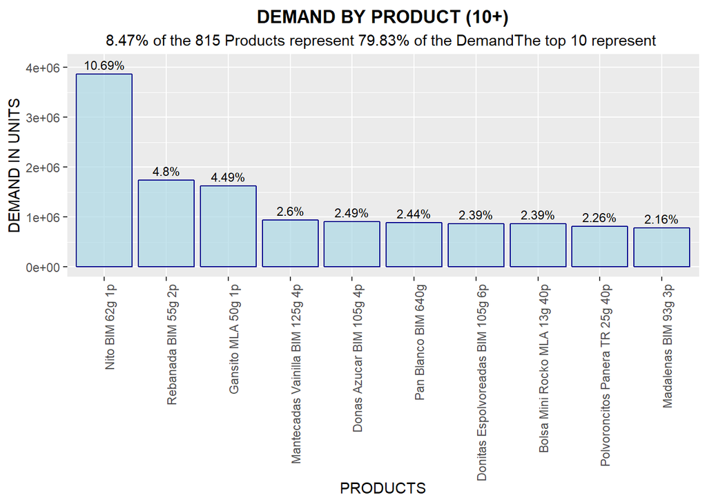

```r
ggplot(demand_by_product[1:10, ],
       aes(x = reorder(Product, -Demanda_uni_equil), y = Demanda_uni_equil)) +
  geom_col(fill = 'lightblue', color = 'darkblue', alpha = 0.7) +
  geom_text(aes(label = paste(Perc, '%', sep = '')), vjust = -0.5, size = 3) +
  ggtitle('DEMAND BY PRODUCT (10+)') +
  xlab('PRODUCTS') +
  ylab('DEMAND IN UNITS') +
  ylim(0, max(demand_by_product$Demanda_uni_equil) * 1.05) +
  labs(subtitle = paste(
    round(nrow(demand_by_product %>% filter(Cum_Perc <= 80)) / nrow(demand_by_product) * 100, 2),
    "% of the ",
    nrow(demand_by_product),
    " Products represent ",
    max(demand_by_product %>% filter(Cum_Perc <= 80) %>% select(Cum_Perc)),
    "% of the Demand",
    'The top 10 represent ',sep = '')) +
  theme(plot.title = element_text(hjust = 0.5, vjust = 0.5, face = 'bold'),
        axis.text.x = element_text(angle = 90, hjust = 1),
        plot.subtitle = element_text(hjust = 0.5, vjust = 0.5))
```

```r
paste(demand_by_product[10, 'Cum_Perc'], '%', sep='')
```

```
## [1] "36.71%"
```

*The top 10 represent 36.71% of the total of the demand*

RETURNED UNITS

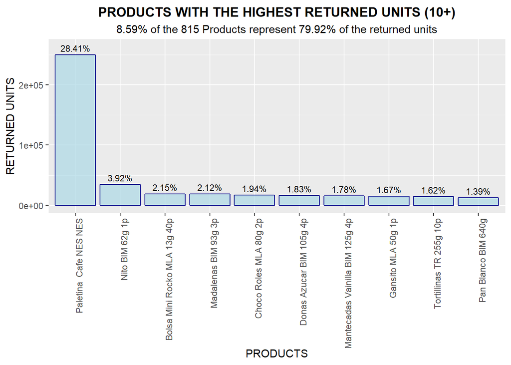

```r
ggplot(return_by_product[1:10, ],
       aes(x = reorder(Product, -Dev_uni_proxima), y = Dev_uni_proxima)) +
  geom_col(fill = 'lightblue', color = 'darkblue', alpha = 0.7) +
  geom_text(aes(label = paste(Perc, '%', sep = '')), vjust = -0.5, size = 3) +
  ggtitle('PRODUCTS WITH THE HIGHEST RETURNED UNITS (10+)') +
  xlab('PRODUCTS') +
  ylab('RETURNED UNITS') +
  ylim(0, max(return_by_product$Dev_uni_proxima) * 1.05) +
  labs(subtitle = paste(
    round(nrow(return_by_product %>% filter(Cum_Perc <= 80)) / nrow(return_by_product) * 100, 2),
    "% of the ",
    nrow(return_by_product),
    " Products represent ",
    max(return_by_product %>% filter(Cum_Perc <= 80) %>% select(Cum_Perc)),
    "% of the returned units", sep = '')) +
  theme(plot.title = element_text(hjust = 0.5, vjust = 0.5, face = 'bold'),
        axis.text.x = element_text(angle = 90, hjust = 1),
        plot.subtitle = element_text(hjust = 0.5, vjust = 0.5))
```

```r
paste(return_by_product[10, 'Cum_Perc'], '%', sep='')
```

```
## [1] "46.82%"
```

*The top 10 represent 46.82% of the total of the returned units*

COST OF RETURN

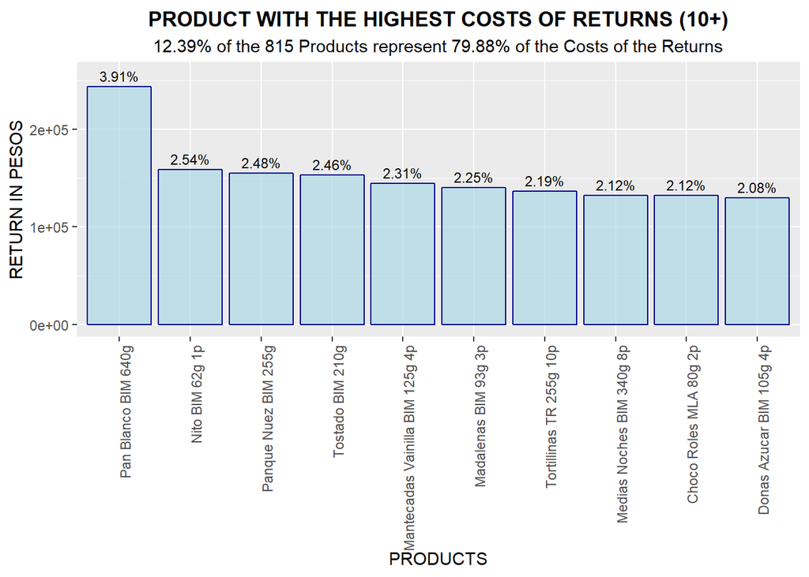

```r
ggplot(cost_by_product[1:10, ],
       aes(x = reorder(Product, -Dev_proxima), y = Dev_proxima)) +
  geom_col(fill = 'lightblue', color = 'darkblue', alpha = 0.7) +
  geom_text(aes(label = paste(Perc, '%', sep = '')), vjust = -0.5, size = 3) +
  ggtitle('PRODUCT WITH THE HIGHEST COSTS OF RETURNS (10+)') +
  xlab('PRODUCTS') +
  ylab('RETURN IN PESOS') +
  ylim(0, max(cost_by_product$Dev_proxima) * 1.05) +
  labs(subtitle = paste(
    round(nrow(cost_by_product %>% filter(Cum_Perc <= 80)) / nrow(cost_by_product) * 100, 2),
    "% of the ",
    nrow(cost_by_product),
    " Products represent ",
    max(cost_by_product %>% filter(Cum_Perc <= 80) %>% select(Cum_Perc)),
    "% of the Costs of the Returns", sep = '')) +
  theme(plot.title = element_text(hjust = 0.5, vjust = 0.5, face = 'bold'),
        axis.text.x = element_text(angle = 90, hjust = 1),
        plot.subtitle = element_text(hjust = 0.5, vjust = 0.5))
```

```r
paste(cost_by_product[10, 'Cum_Perc'], '%', sep='')
```

```
## [1] "24.48%"
```

*The top 10 represent 24.48% of the total of the costs with returns*

**As seen above, a small parcel of the products represent 80% of de DEMAND, RETURNED UNITS AND COSTS WITH RETURNS.** **At this point it’s being considered to address through the products which represent about 80% of the returned units in a trying to reduce wastes. By focusing on the features with the most returns, it can be reached multiple benefits, for example: costs reduction, better use of transports, improvement on the relationship with clients.**

List of products which represent about 80% of the returns

```r
list_products <- as.vector(unlist(return_by_product %>% filter(Cum_Perc <= 80) %>% select(Product)))
```

## Towns Analysis using the list of products which represent 80% of the total of returned units

```r
towns_analysis <- train_set %>% filter(Product %in% list_products) %>% select(Town, Venta_uni_hoy, Venta_hoy, Dev_uni_proxima, Dev_proxima, Demanda_uni_equil)
towns_analysis <- distinct(towns_analysis %>%
                                group_by(Town) %>%
                                mutate(
                                  Venta_uni_hoy = sum(Venta_uni_hoy),
                                  Venta_hoy = sum(Venta_hoy),
                                  Dev_uni_proxima = sum(Dev_uni_proxima),
                                  Dev_proxima = sum(Dev_proxima),
                                  Demanda_uni_equil = sum(Demanda_uni_equil)
                                ), Town, .keep_all = T)
```

Checking the number of locations

```r
length(unique(towns_analysis$Town))
```

```
## [1] 252
```

Demand by town

```r
demand_by_town <- data.frame(towns_analysis[order(-towns_analysis$Demanda_uni_equil),][,c(1, 6)])
demand_by_town <- demand_by_town %>% mutate(
  Cum_Demand = cumsum(Demanda_uni_equil),
  Perc = round((Demanda_uni_equil / sum(Demanda_uni_equil)) * 100 , 2),
  Cum_Perc = round((Cum_Demand / sum(Demanda_uni_equil)) * 100 , 2)
)
```

Table of the towns which correspond 80% of the total of the demand of the list_products

```r
kable(demand_by_town %>% filter(Cum_Perc <= 80))
```

| Town | Demanda_uni_equil | Cum_Demand | Perc | Cum_Perc |
| --- | --- | --- | --- | --- |
| 2011 AG. SAN ANTONIO | 397752 | 397752 | 1.46 | 1.46 |
| 2013 AG. MEGA NAUCALPAN | 344839 | 742591 | 1.27 | 2.73 |
| 2309 NORTE | 332766 | 1075357 | 1.23 | 3.96 |
| 2017 AG. SANTA CLARA | 282758 | 1358115 | 1.04 | 5.00 |
| 2251 AGUASCALIENTES NORTE | 265671 | 1623786 | 0.98 | 5.98 |
| 2019 AG. XALOSTOC | 261015 | 1884801 | 0.96 | 6.94 |
| 2278 ZAPOPAN BIMBO | 256775 | 2141576 | 0.95 | 7.89 |
| 2088 AG. CEYLAN | 253585 | 2395161 | 0.93 | 8.82 |
| 2001 AG. ATIZAPAN | 247143 | 2642304 | 0.91 | 9.73 |
| 2294 GUADALAJARA | 243526 | 2885830 | 0.90 | 10.63 |
| 2268 PALOMAR | 235363 | 3121193 | 0.87 | 11.49 |
| 2007 AG. LA VILLA | 233601 | 3354794 | 0.86 | 12.35 |
| 2322 ZAMORA MADERO | 232632 | 3587426 | 0.86 | 13.21 |
| 2252 AGUASCALIENTES SIGLO XXI | 232062 | 3819488 | 0.85 | 14.07 |
| 2029 AG.IZTAPALAPA 2 | 231621 | 4051109 | 0.85 | 14.92 |
| 2273 SAN PEDRO | 227024 | 4278133 | 0.84 | 15.75 |
| 2048 AG. IXTAPALUCA 1 | 218127 | 4496260 | 0.80 | 16.56 |
| 2057 PUEBLA SUR MARINELA | 216635 | 4712895 | 0.80 | 17.36 |
| 2515 CAVAZOS | 215814 | 4928709 | 0.79 | 18.15 |
| 2293 GRANJAS MARINELA | 212850 | 5141559 | 0.78 | 18.93 |
| 2165 LEON SAN JUAN BOSCO | 211609 | 5353168 | 0.78 | 19.71 |
| 2167 MORELIA LA HUERTA | 205962 | 5559130 | 0.76 | 20.47 |
| 2467 LINCOLN | 205549 | 5764679 | 0.76 | 21.23 |
| 2094 CHALCO_BM | 202595 | 5967274 | 0.75 | 21.97 |
| 2300 LEON MILENIUM | 202123 | 6169397 | 0.74 | 22.72 |
| 2041 AG. TULTITLAN | 198609 | 6368006 | 0.73 | 23.45 |
| 2402 TUXTLA | 194645 | 6562651 | 0.72 | 24.17 |
| 2177 AGENCIA SUANDY | 192154 | 6754805 | 0.71 | 24.87 |
| 2487 AEROPUERTO | 190912 | 6945717 | 0.70 | 25.58 |
| 2190 BI_SAN FRANCISCO DEL RINCON | 189455 | 7135172 | 0.70 | 26.27 |

[output cut: 112 more lines]

Return by town

```r
return_by_town <- data.frame(towns_analysis[order(-towns_analysis$Dev_uni_proxima),][,c(1, 4)])
return_by_town <- return_by_town %>% mutate(
  Cum_Dev = cumsum(Dev_uni_proxima),
  Perc = round((Dev_uni_proxima / sum(Dev_uni_proxima)) * 100 , 2),
  Cum_Perc = round((Cum_Dev / sum(Dev_uni_proxima)) * 100 , 2)
)
```

Table of the towns which correspond 80% of the total of returned units of the list_products

```r
kable(return_by_town %>% filter(Cum_Perc <= 80))
```

| Town | Dev_uni_proxima | Cum_Dev | Perc | Cum_Perc |
| --- | --- | --- | --- | --- |
| 2088 AG. CEYLAN | 254766 | 254766 | 36.23 | 36.23 |
| 2029 AG.IZTAPALAPA 2 | 7438 | 262204 | 1.06 | 37.28 |
| 2013 AG. MEGA NAUCALPAN | 6221 | 268425 | 0.88 | 38.17 |
| 2059 QUERETARO BALVANERA | 6159 | 274584 | 0.88 | 39.04 |
| 2041 AG. TULTITLAN | 4934 | 279518 | 0.70 | 39.75 |
| 2355 JALAPA I | 4820 | 284338 | 0.69 | 40.43 |
| 2309 NORTE | 4819 | 289157 | 0.69 | 41.12 |
| 2057 PUEBLA SUR MARINELA | 4811 | 293968 | 0.68 | 41.80 |
| 2293 GRANJAS MARINELA | 4777 | 298745 | 0.68 | 42.48 |
| 2251 AGUASCALIENTES NORTE | 4612 | 303357 | 0.66 | 43.13 |
| 2485 CHIHUAHUA MARINELA | 4324 | 307681 | 0.61 | 43.75 |
| 2505 TORREON | 4120 | 311801 | 0.59 | 44.34 |
| 2177 AGENCIA SUANDY | 3876 | 315677 | 0.55 | 44.89 |
| 2260 GONZALEZ GALLO | 3824 | 319501 | 0.54 | 45.43 |
| 2402 TUXTLA | 3808 | 323309 | 0.54 | 45.97 |
| 2167 MORELIA LA HUERTA | 3783 | 327092 | 0.54 | 46.51 |
| 2001 AG. ATIZAPAN | 3760 | 330852 | 0.53 | 47.04 |
| 2158 CUERNAVACA CIVAC | 3730 | 334582 | 0.53 | 47.57 |
| 2365 PUEBLA SUR BIMBO | 3723 | 338305 | 0.53 | 48.10 |
| 2517 SENDERO AUTOSERVICIO | 3657 | 341962 | 0.52 | 48.62 |
| 2462 JUAREZ BIMBO | 3629 | 345591 | 0.52 | 49.14 |
| 2273 SAN PEDRO | 3611 | 349202 | 0.51 | 49.65 |
| 2056 PUEBLA NORTE MARINELA | 3511 | 352713 | 0.50 | 50.15 |
| 2515 CAVAZOS | 3476 | 356189 | 0.49 | 50.65 |
| 2294 GUADALAJARA | 3458 | 359647 | 0.49 | 51.14 |
| 2042 AG. TEPOZOTLAN | 3445 | 363092 | 0.49 | 51.63 |
| 2268 PALOMAR | 3388 | 366480 | 0.48 | 52.11 |
| 2036 APIZACO MARINELA | 3382 | 369862 | 0.48 | 52.59 |
| 2044 CUERNAVACA BUENAVISTA | 3365 | 373227 | 0.48 | 53.07 |
| 2272 SAN LUIS REY | 3328 | 376555 | 0.47 | 53.54 |

[output cut: 76 more lines]

Cost of return by town

```r
cost_by_town <- data.frame(towns_analysis[order(-towns_analysis$Dev_proxima),][,c(1, 5)])
cost_by_town <- cost_by_town %>% mutate(
  Cum_Dev = cumsum(Dev_proxima),
  Perc = round((Dev_proxima / sum(Dev_proxima)) * 100 , 2),
  Cum_Perc = round((Cum_Dev / sum(Dev_proxima)) * 100 , 2)
)
```

Table of the towns which correspond 80% of the total of the costs with returns of the list_products

```r
kable(cost_by_town %>% filter(Cum_Perc <= 80))
```

| Town | Dev_proxima | Cum_Dev | Perc | Cum_Perc |
| --- | --- | --- | --- | --- |
| 2029 AG.IZTAPALAPA 2 | 95916.00 | 95916.0 | 2.24 | 2.24 |
| 2013 AG. MEGA NAUCALPAN | 66931.90 | 162847.9 | 1.56 | 3.80 |
| 2355 JALAPA I | 62897.70 | 225745.6 | 1.47 | 5.26 |
| 2293 GRANJAS MARINELA | 62647.98 | 288393.6 | 1.46 | 6.72 |
| 2517 SENDERO AUTOSERVICIO | 54547.34 | 342940.9 | 1.27 | 7.99 |
| 2059 QUERETARO BALVANERA | 50007.44 | 392948.4 | 1.17 | 9.16 |
| 2041 AG. TULTITLAN | 48098.70 | 441047.1 | 1.12 | 10.28 |
| 2088 AG. CEYLAN | 46572.17 | 487619.2 | 1.09 | 11.37 |
| 2505 TORREON | 46257.39 | 533876.6 | 1.08 | 12.44 |
| 2309 NORTE | 44626.03 | 578502.7 | 1.04 | 13.48 |
| 2462 JUAREZ BIMBO | 44056.06 | 622558.7 | 1.03 | 14.51 |
| 2496 LA FE | 41063.11 | 663621.8 | 0.96 | 15.47 |
| 2057 PUEBLA SUR MARINELA | 38720.07 | 702341.9 | 0.90 | 16.37 |
| 2485 CHIHUAHUA MARINELA | 38580.97 | 740922.9 | 0.90 | 17.27 |
| 2477 SALTILLO BIMBO | 37976.15 | 778899.0 | 0.89 | 18.15 |
| 2402 TUXTLA | 36581.26 | 815480.3 | 0.85 | 19.01 |
| 2001 AG. ATIZAPAN | 35227.65 | 850707.9 | 0.82 | 19.83 |
| 2177 AGENCIA SUANDY | 34607.98 | 885315.9 | 0.81 | 20.63 |
| 2365 PUEBLA SUR BIMBO | 33736.97 | 919052.9 | 0.79 | 21.42 |
| 2158 CUERNAVACA CIVAC | 33312.92 | 952365.8 | 0.78 | 22.20 |
| 2251 AGUASCALIENTES NORTE | 33210.94 | 985576.7 | 0.77 | 22.97 |
| 2260 GONZALEZ GALLO | 32765.19 | 1018341.9 | 0.76 | 23.74 |
| 2044 CUERNAVACA BUENAVISTA | 32411.35 | 1050753.3 | 0.76 | 24.49 |
| 2289 CULIACAN MARINELA | 32297.96 | 1083051.2 | 0.75 | 25.24 |
| 2165 LEON SAN JUAN BOSCO | 31709.77 | 1114761.0 | 0.74 | 25.98 |
| 2269 PUERTO VALLARTA BIMBO | 31549.22 | 1146310.2 | 0.74 | 26.72 |
| 2094 CHALCO_BM | 31295.17 | 1177605.4 | 0.73 | 27.45 |
| 2273 SAN PEDRO | 30897.13 | 1208502.5 | 0.72 | 28.17 |
| 2167 MORELIA LA HUERTA | 30867.05 | 1239369.6 | 0.72 | 28.89 |
| 2011 AG. SAN ANTONIO | 29669.11 | 1269038.7 | 0.69 | 29.58 |

[output cut: 104 more lines]

**Plots of the top 10 Towns which correspond 80% of the DEMAND, RETURN (UNITS) and COST WITH RETURN** **It’s been shown only the top 10 because of the legibility of the plots**

DEMAND

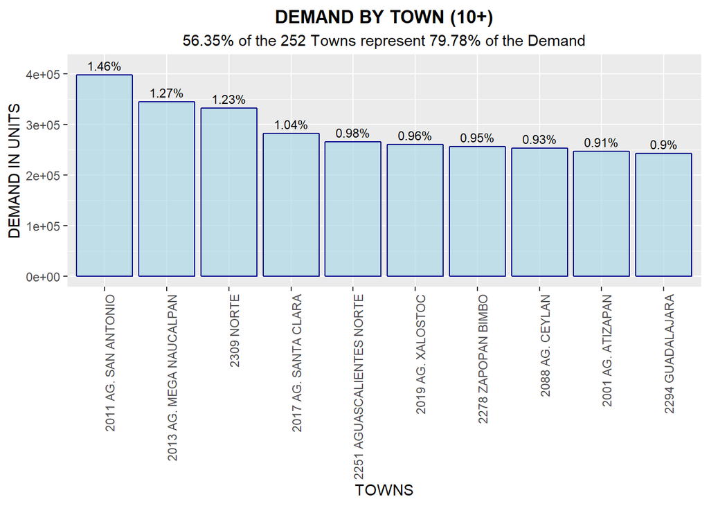

```r
ggplot(demand_by_town[1:10, ] %>% filter(Cum_Perc <= 80),
       aes(x = reorder(Town, -Demanda_uni_equil), y = Demanda_uni_equil)) +
  geom_col(fill = 'lightblue', color = 'darkblue', alpha = 0.7) +
  geom_text(aes(label = paste(Perc, '%', sep = '')), vjust = -0.5, size = 3) +
  ggtitle('DEMAND BY TOWN (10+)') +
  xlab('TOWNS') +
  ylab('DEMAND IN UNITS') +
  ylim(0, max(demand_by_town$Demanda_uni_equil) * 1.05) +
  labs(subtitle = paste(
    round(nrow(demand_by_town %>% filter(Cum_Perc <= 80)) / nrow(demand_by_town) * 100, 2),
    "% of the ",
    nrow(demand_by_town),
    " Towns represent ",
    max(demand_by_town %>% filter(Cum_Perc <= 80) %>% select(Cum_Perc)),
    "% of the Demand", sep = '')) +
  theme(plot.title = element_text(hjust = 0.5, vjust = 0.5, face = 'bold'),
        axis.text.x = element_text(angle = 90, hjust = 1),
        plot.subtitle = element_text(hjust = 0.5, vjust = 0.5))
```

```r
paste(demand_by_town[10, 'Cum_Perc'], '%', sep='')
```

```
## [1] "10.63%"
```

*The top 10 represent 10.63% of the total of demand*

RETURNED UNITS

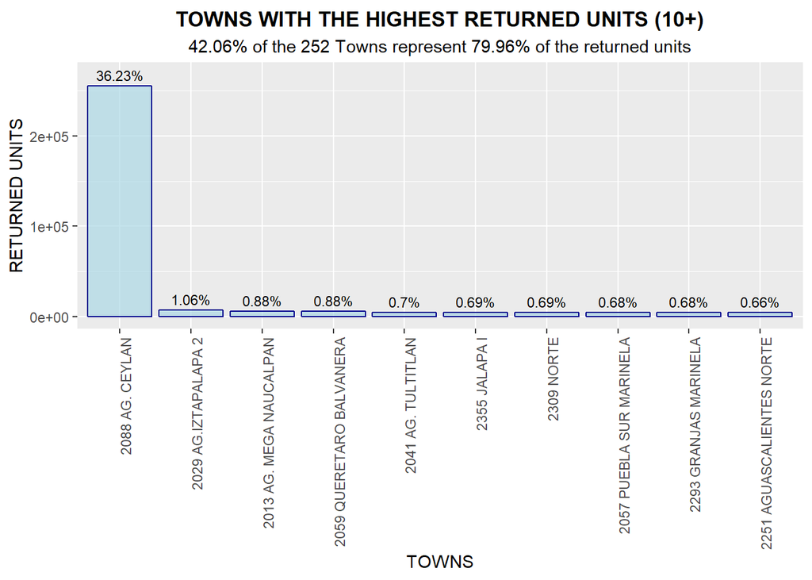

```r
ggplot(return_by_town[1:10, ] %>% filter(Cum_Perc <= 80),
       aes(x = reorder(Town, -Dev_uni_proxima), y = Dev_uni_proxima)) +
  geom_col(fill = 'lightblue', color = 'darkblue', alpha = 0.7) +
  geom_text(aes(label = paste(Perc, '%', sep = '')), vjust = -0.5, size = 3) +
  ggtitle('TOWNS WITH THE HIGHEST RETURNED UNITS (10+)') +
  xlab('TOWNS') +
  ylab('RETURNED UNITS') +
  ylim(0, max(return_by_town$Dev_uni_proxima) * 1.05) +
  labs(subtitle = paste(
    round(nrow(return_by_town %>% filter(Cum_Perc <= 80)) / nrow(return_by_town) * 100, 2),
    "% of the ",
    nrow(return_by_town),
    " Towns represent ",
    max(return_by_town %>% filter(Cum_Perc <= 80) %>% select(Cum_Perc)),
    "% of the returned units", sep = '')) +
  theme(plot.title = element_text(hjust = 0.5, vjust = 0.5, face = 'bold'),
        axis.text.x = element_text(angle = 90, hjust = 1),
        plot.subtitle = element_text(hjust = 0.5, vjust = 0.5))
```

```r
paste(return_by_town[10, 'Cum_Perc'], '%', sep='')
```

```
## [1] "43.13%"
```

*The top 10 represent 43.13% of the total of the returned units*

COST OF RETURN

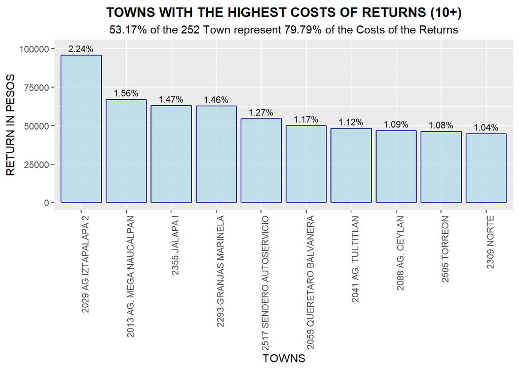

```r
ggplot(cost_by_town[1:10, ] %>% filter(Cum_Perc <= 80),
       aes(x = reorder(Town, -Dev_proxima), y = Dev_proxima)) +
  geom_col(fill = 'lightblue', color = 'darkblue', alpha = 0.7) +
  geom_text(aes(label = paste(Perc, '%', sep = '')), vjust = -0.5, size = 3) +
  ggtitle('TOWNS WITH THE HIGHEST COSTS OF RETURNS (10+)') +
  xlab('TOWNS') +
  ylab('RETURN IN PESOS') +
  ylim(0, max(cost_by_town$Dev_proxima) * 1.05) +
  labs(subtitle = paste(
    round(nrow(cost_by_town %>% filter(Cum_Perc <= 80)) / nrow(cost_by_town) * 100, 2),
    "% of the ",
    nrow(cost_by_town),
    " Town represent ",
    max(cost_by_town %>% filter(Cum_Perc <= 80) %>% select(Cum_Perc)),
    "% of the Costs of the Returns", sep = '')) +
  theme(plot.title = element_text(hjust = 0.5, vjust = 0.5, face = 'bold'),
        axis.text.x = element_text(angle = 90, hjust = 1),
        plot.subtitle = element_text(hjust = 0.5, vjust = 0.5))
```

```r
paste(cost_by_town[10, 'Cum_Perc'], '%', sep='')
```

```
## [1] "13.48%"
```

*The top 10 represent 13.48% of the total of the costs with return*

**As the first sub selection, it’ being considered only the 80% of the returned units from the list_products** List of towns which represent about 80% of the returns of the list_products

```r
list_towns <- as.vector(unlist(return_by_town %>% filter(Cum_Perc <= 80) %>% select(Town)))
```

```r
clients_analysis <- train_set %>% filter(Product %in% list_products & Town %in% list_towns) %>% select(NombreCliente, Venta_uni_hoy, Venta_hoy, Dev_uni_proxima, Dev_proxima, Demanda_uni_equil)
clients_analysis <- distinct(clients_analysis %>%
                             group_by(NombreCliente) %>%
                             mutate(
                               Venta_uni_hoy = sum(Venta_uni_hoy),
                               Venta_hoy = sum(Venta_hoy),
                               Dev_uni_proxima = sum(Dev_uni_proxima),
                               Dev_proxima = sum(Dev_proxima),
                               Demanda_uni_equil = sum(Demanda_uni_equil)
                             ), NombreCliente, .keep_all = T)
```

Checking the number of locations

```r
length(unique(clients_analysis$NombreCliente))
```

```
## [1] 152600
```

**Since the number of clients is too high, it will be calculated only the clients which represent 80% of returns of the list_towns, keeping the same approach**

Return by product

```r
demand_by_client <- data.frame(clients_analysis[order(-clients_analysis$Demanda_uni_equil),][,c(1, 6)])
demand_by_client <- demand_by_client %>% mutate(
  Cum_Dev = cumsum(Demanda_uni_equil),
  Perc = round((Demanda_uni_equil / sum(Demanda_uni_equil)) * 100 , 2),
  Cum_Perc = round((Cum_Dev / sum(Demanda_uni_equil)) * 100 , 2)
)
```

Table of the clients which correspond 80% of the total of the demand of the list_towns

```r
kable(head(demand_by_client %>% filter(Cum_Perc <= 80), 50), caption = '50 first results')
```

50 first results

| NombreCliente | Demanda_uni_equil | Cum_Dev | Perc | Cum_Perc |
| --- | --- | --- | --- | --- |
| NO IDENTIFICADO | 2676577 | 2676577 | 16.30 | 16.30 |
| PUEBLA REMISION | 277864 | 2954441 | 1.69 | 18.00 |
| LUPITA | 83629 | 3038070 | 0.51 | 18.51 |
| MARY | 50168 | 3088238 | 0.31 | 18.81 |
| LA PASADITA | 36373 | 3124611 | 0.22 | 19.03 |
| LA VENTANITA | 31042 | 3155653 | 0.19 | 19.22 |
| QUERETARO DE ARTEAGA REMISION | 30648 | 3186301 | 0.19 | 19.41 |
| LA GUADALUPANA | 26355 | 3212656 | 0.16 | 19.57 |
| ALEX | 24487 | 3237143 | 0.15 | 19.72 |
| PATY | 22381 | 3259524 | 0.14 | 19.85 |
| DANY | 21702 | 3281226 | 0.13 | 19.99 |
| LA PROVIDENCIA | 21315 | 3302541 | 0.13 | 20.12 |
| LA ESPERANZA | 21292 | 3323833 | 0.13 | 20.25 |
| ROSY | 20872 | 3344705 | 0.13 | 20.37 |
| GABY | 20675 | 3365380 | 0.13 | 20.50 |
| LA CHIQUITA | 20568 | 3385948 | 0.13 | 20.62 |
| LA ESCONDIDA | 19324 | 3405272 | 0.12 | 20.74 |
| HERNANDEZ | 19041 | 3424313 | 0.12 | 20.86 |
| LA ESQUINA | 18466 | 3442779 | 0.11 | 20.97 |
| MARTINEZ | 17781 | 3460560 | 0.11 | 21.08 |
| GARCIA | 17459 | 3478019 | 0.11 | 21.18 |
| SAN JOSE | 17247 | 3495266 | 0.11 | 21.29 |
| LA ESTRELLA | 16944 | 3512210 | 0.10 | 21.39 |
| JUQUILITA | 16067 | 3528277 | 0.10 | 21.49 |
| DIANA | 15977 | 3544254 | 0.10 | 21.59 |
| GONZALEZ | 15453 | 3559707 | 0.09 | 21.68 |
| LA NUEVA | 14836 | 3574543 | 0.09 | 21.77 |
| LETY | 14554 | 3589097 | 0.09 | 21.86 |
| LUCY | 13968 | 3603065 | 0.09 | 21.95 |
| 3 HERMANOS | 13673 | 3616738 | 0.08 | 22.03 |
| EL GUERO | 13503 | 3630241 | 0.08 | 22.11 |
| LA TIENDITA | 12592 | 3642833 | 0.08 | 22.19 |
| FLORES | 12358 | 3655191 | 0.08 | 22.26 |
| LA LUPITA | 12346 | 3667537 | 0.08 | 22.34 |
| MI TIENDITA | 12318 | 3679855 | 0.08 | 22.41 |
| GLORIA | 12215 | 3692070 | 0.07 | 22.49 |
| KAREN | 11929 | 3703999 | 0.07 | 22.56 |
| TERE | 11697 | 3715696 | 0.07 | 22.63 |
| VERO | 11538 | 3727234 | 0.07 | 22.70 |
| JALISCO REMISION | 11489 | 3738723 | 0.07 | 22.77 |
| LOS ANGELES | 11431 | 3750154 | 0.07 | 22.84 |
| SUSY | 11148 | 3761302 | 0.07 | 22.91 |
| LEO | 11102 | 3772404 | 0.07 | 22.98 |
| RODRIGUEZ | 11075 | 3783479 | 0.07 | 23.05 |
| ANITA | 10947 | 3794426 | 0.07 | 23.11 |
| LOPEZ | 10893 | 3805319 | 0.07 | 23.18 |
| CARMELITA | 10640 | 3815959 | 0.06 | 23.24 |
| DICONSA | 10549 | 3826508 | 0.06 | 23.31 |
| LA FE | 10356 | 3836864 | 0.06 | 23.37 |
| SANDY | 10316 | 3847180 | 0.06 | 23.43 |

```r
return_by_client <- data.frame(clients_analysis[order(-clients_analysis$Dev_uni_proxima),][,c(1, 4)])
return_by_client <- return_by_client %>% mutate(
  Cum_Dev = cumsum(Dev_uni_proxima),
  Perc = round((Dev_uni_proxima / sum(Dev_uni_proxima)) * 100 , 2),
  Cum_Perc = round((Cum_Dev / sum(Dev_uni_proxima)) * 100 , 2)
)
```

```r
kable(head(return_by_town %>% filter(Cum_Perc <= 80), 50), caption = '50 first results')
```

50 first results

| Town | Dev_uni_proxima | Cum_Dev | Perc | Cum_Perc |
| --- | --- | --- | --- | --- |
| 2088 AG. CEYLAN | 254766 | 254766 | 36.23 | 36.23 |
| 2029 AG.IZTAPALAPA 2 | 7438 | 262204 | 1.06 | 37.28 |
| 2013 AG. MEGA NAUCALPAN | 6221 | 268425 | 0.88 | 38.17 |
| 2059 QUERETARO BALVANERA | 6159 | 274584 | 0.88 | 39.04 |
| 2041 AG. TULTITLAN | 4934 | 279518 | 0.70 | 39.75 |
| 2355 JALAPA I | 4820 | 284338 | 0.69 | 40.43 |
| 2309 NORTE | 4819 | 289157 | 0.69 | 41.12 |
| 2057 PUEBLA SUR MARINELA | 4811 | 293968 | 0.68 | 41.80 |
| 2293 GRANJAS MARINELA | 4777 | 298745 | 0.68 | 42.48 |
| 2251 AGUASCALIENTES NORTE | 4612 | 303357 | 0.66 | 43.13 |
| 2485 CHIHUAHUA MARINELA | 4324 | 307681 | 0.61 | 43.75 |
| 2505 TORREON | 4120 | 311801 | 0.59 | 44.34 |
| 2177 AGENCIA SUANDY | 3876 | 315677 | 0.55 | 44.89 |
| 2260 GONZALEZ GALLO | 3824 | 319501 | 0.54 | 45.43 |
| 2402 TUXTLA | 3808 | 323309 | 0.54 | 45.97 |
| 2167 MORELIA LA HUERTA | 3783 | 327092 | 0.54 | 46.51 |
| 2001 AG. ATIZAPAN | 3760 | 330852 | 0.53 | 47.04 |
| 2158 CUERNAVACA CIVAC | 3730 | 334582 | 0.53 | 47.57 |
| 2365 PUEBLA SUR BIMBO | 3723 | 338305 | 0.53 | 48.10 |
| 2517 SENDERO AUTOSERVICIO | 3657 | 341962 | 0.52 | 48.62 |
| 2462 JUAREZ BIMBO | 3629 | 345591 | 0.52 | 49.14 |
| 2273 SAN PEDRO | 3611 | 349202 | 0.51 | 49.65 |
| 2056 PUEBLA NORTE MARINELA | 3511 | 352713 | 0.50 | 50.15 |
| 2515 CAVAZOS | 3476 | 356189 | 0.49 | 50.65 |
| 2294 GUADALAJARA | 3458 | 359647 | 0.49 | 51.14 |
| 2042 AG. TEPOZOTLAN | 3445 | 363092 | 0.49 | 51.63 |
| 2268 PALOMAR | 3388 | 366480 | 0.48 | 52.11 |
| 2036 APIZACO MARINELA | 3382 | 369862 | 0.48 | 52.59 |
| 2044 CUERNAVACA BUENAVISTA | 3365 | 373227 | 0.48 | 53.07 |
| 2272 SAN LUIS REY | 3328 | 376555 | 0.47 | 53.54 |
| 2269 PUERTO VALLARTA BIMBO | 3261 | 379816 | 0.46 | 54.01 |
| 2094 CHALCO_BM | 3161 | 382977 | 0.45 | 54.46 |
| 2165 LEON SAN JUAN BOSCO | 3158 | 386135 | 0.45 | 54.91 |
| 2382 CARDENAS | 3072 | 389207 | 0.44 | 55.34 |
| 2063 TEHUACAN MARINELA | 3070 | 392277 | 0.44 | 55.78 |
| 2161 IRAPUATO GUADALUPE | 3060 | 395337 | 0.44 | 56.21 |
| 2059 Queretaro Balvanera | 3034 | 398371 | 0.43 | 56.64 |
| 2034 ACAPULCO COSTERA | 3011 | 401382 | 0.43 | 57.07 |
| 2392 MERIDA NORTE | 3008 | 404390 | 0.43 | 57.50 |
| 2407 TEPEACA | 3007 | 407397 | 0.43 | 57.93 |
| 2477 SALTILLO BIMBO | 2994 | 410391 | 0.43 | 58.35 |
| 2190 BI_SAN FRANCISCO DEL RINCON | 2985 | 413376 | 0.42 | 58.78 |
| 2278 ZAPOPAN BIMBO | 2948 | 416324 | 0.42 | 59.20 |
| 2396 RUIZ CORTINEZ | 2900 | 419224 | 0.41 | 59.61 |
| 2155 CELAYA NORPONIENTE | 2879 | 422103 | 0.41 | 60.02 |
| 2496 LA FE | 2835 | 424938 | 0.40 | 60.42 |
| 2017 AG. SANTA CLARA | 2792 | 427730 | 0.40 | 60.82 |
| 2011 AG. SAN ANTONIO | 2789 | 430519 | 0.40 | 61.22 |
| 2010 AG. LOS REYES | 2763 | 433282 | 0.39 | 61.61 |
| 2363 POZA RICA | 2756 | 436038 | 0.39 | 62.00 |

```r
cost_by_client <- data.frame(clients_analysis[order(-clients_analysis$Dev_proxima),][,c(1, 5)])
cost_by_client <- cost_by_client %>% mutate(
  Cum_Dev = cumsum(Dev_proxima),
  Perc = round((Dev_proxima / sum(Dev_proxima)) * 100 , 2),
  Cum_Perc = round((Cum_Dev / sum(Dev_proxima)) * 100 , 2)
)
```

```r
kable(head(cost_by_town %>% filter(Cum_Perc <= 80), 50), caption = '50 first results')
```

50 first results

| Town | Dev_proxima | Cum_Dev | Perc | Cum_Perc |
| --- | --- | --- | --- | --- |
| 2029 AG.IZTAPALAPA 2 | 95916.00 | 95916.0 | 2.24 | 2.24 |
| 2013 AG. MEGA NAUCALPAN | 66931.90 | 162847.9 | 1.56 | 3.80 |
| 2355 JALAPA I | 62897.70 | 225745.6 | 1.47 | 5.26 |
| 2293 GRANJAS MARINELA | 62647.98 | 288393.6 | 1.46 | 6.72 |
| 2517 SENDERO AUTOSERVICIO | 54547.34 | 342940.9 | 1.27 | 7.99 |
| 2059 QUERETARO BALVANERA | 50007.44 | 392948.4 | 1.17 | 9.16 |
| 2041 AG. TULTITLAN | 48098.70 | 441047.1 | 1.12 | 10.28 |
| 2088 AG. CEYLAN | 46572.17 | 487619.2 | 1.09 | 11.37 |
| 2505 TORREON | 46257.39 | 533876.6 | 1.08 | 12.44 |
| 2309 NORTE | 44626.03 | 578502.7 | 1.04 | 13.48 |
| 2462 JUAREZ BIMBO | 44056.06 | 622558.7 | 1.03 | 14.51 |
| 2496 LA FE | 41063.11 | 663621.8 | 0.96 | 15.47 |
| 2057 PUEBLA SUR MARINELA | 38720.07 | 702341.9 | 0.90 | 16.37 |
| 2485 CHIHUAHUA MARINELA | 38580.97 | 740922.9 | 0.90 | 17.27 |
| 2477 SALTILLO BIMBO | 37976.15 | 778899.0 | 0.89 | 18.15 |
| 2402 TUXTLA | 36581.26 | 815480.3 | 0.85 | 19.01 |
| 2001 AG. ATIZAPAN | 35227.65 | 850707.9 | 0.82 | 19.83 |
| 2177 AGENCIA SUANDY | 34607.98 | 885315.9 | 0.81 | 20.63 |
| 2365 PUEBLA SUR BIMBO | 33736.97 | 919052.9 | 0.79 | 21.42 |
| 2158 CUERNAVACA CIVAC | 33312.92 | 952365.8 | 0.78 | 22.20 |
| 2251 AGUASCALIENTES NORTE | 33210.94 | 985576.7 | 0.77 | 22.97 |
| 2260 GONZALEZ GALLO | 32765.19 | 1018341.9 | 0.76 | 23.74 |
| 2044 CUERNAVACA BUENAVISTA | 32411.35 | 1050753.3 | 0.76 | 24.49 |
| 2289 CULIACAN MARINELA | 32297.96 | 1083051.2 | 0.75 | 25.24 |
| 2165 LEON SAN JUAN BOSCO | 31709.77 | 1114761.0 | 0.74 | 25.98 |
| 2269 PUERTO VALLARTA BIMBO | 31549.22 | 1146310.2 | 0.74 | 26.72 |
| 2094 CHALCO_BM | 31295.17 | 1177605.4 | 0.73 | 27.45 |
| 2273 SAN PEDRO | 30897.13 | 1208502.5 | 0.72 | 28.17 |
| 2167 MORELIA LA HUERTA | 30867.05 | 1239369.6 | 0.72 | 28.89 |
| 2011 AG. SAN ANTONIO | 29669.11 | 1269038.7 | 0.69 | 29.58 |
| 2359 AG.MIXQUIAHUALA | 29348.60 | 1298387.3 | 0.68 | 30.26 |
| 2294 GUADALAJARA | 29333.45 | 1327720.7 | 0.68 | 30.95 |
| 2455 CHIHUAHUA BIMBO | 28991.97 | 1356712.7 | 0.68 | 31.62 |
| 2056 PUEBLA NORTE MARINELA | 28911.53 | 1385624.2 | 0.67 | 32.30 |
| 2161 IRAPUATO GUADALUPE | 28685.55 | 1414309.8 | 0.67 | 32.96 |
| 2042 AG. TEPOZOTLAN | 28531.41 | 1442841.2 | 0.66 | 33.63 |
| 2036 APIZACO MARINELA | 28432.96 | 1471274.1 | 0.66 | 34.29 |
| 2392 MERIDA NORTE | 28278.97 | 1499553.1 | 0.66 | 34.95 |
| 2268 PALOMAR | 28081.98 | 1527635.1 | 0.65 | 35.61 |
| 2386 COATZACOALCOS MLA. | 27935.50 | 1555570.6 | 0.65 | 36.26 |
| 2017 AG. SANTA CLARA | 27725.14 | 1583295.7 | 0.65 | 36.90 |
| 2396 RUIZ CORTINEZ | 27538.57 | 1610834.3 | 0.64 | 37.54 |
| 2010 AG. LOS REYES | 27359.66 | 1638194.0 | 0.64 | 38.18 |
| 2190 BI_SAN FRANCISCO DEL RINCON | 27314.03 | 1665508.0 | 0.64 | 38.82 |
| 2562 MEXICALI PLAZA | 27189.71 | 1692697.7 | 0.63 | 39.45 |
| 2363 POZA RICA | 26293.93 | 1718991.6 | 0.61 | 40.07 |
| 2468 MATAMOROS BIMBO | 26196.35 | 1745188.0 | 0.61 | 40.68 |
| 2467 LINCOLN | 26140.02 | 1771328.0 | 0.61 | 41.29 |
| 2021 AG. XOCHIMILCO 2 | 25654.78 | 1796982.8 | 0.60 | 41.88 |
| 2272 SAN LUIS REY | 25645.58 | 1822628.4 | 0.60 | 42.48 |

**Plots of the top 10 Clients which correspond 80% of the DEMAND, RETURN (UNITS) and COST WITH RETURN** **It’s been shown only the top 10 because of the legibility of the plots**

DEMAND

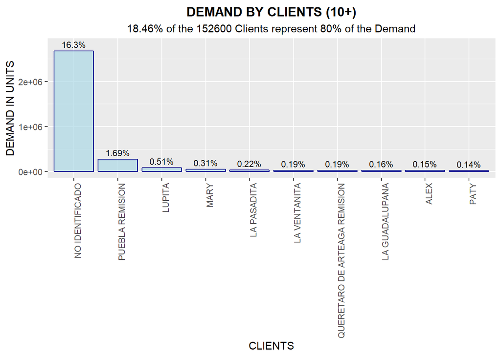

```r
ggplot(demand_by_client[1:10, ],
       aes(x = reorder(NombreCliente, -Demanda_uni_equil), y = Demanda_uni_equil)) +
  geom_col(fill = 'lightblue', color = 'darkblue', alpha = 0.7) +
  geom_text(aes(label = paste(Perc, '%', sep = '')), vjust = -0.5, size = 3) +
  ggtitle('DEMAND BY CLIENTS (10+)') +
  xlab('CLIENTS') +
  ylab('DEMAND IN UNITS') +
  ylim(0, max(demand_by_client$Demanda_uni_equil) * 1.05) +
  labs(subtitle = paste(
    round(nrow(demand_by_client %>% filter(Cum_Perc <= 80)) / nrow(demand_by_client) * 100, 2),
    "% of the ",
    nrow(demand_by_client),
    " Clients represent ",
    max(demand_by_client %>% filter(Cum_Perc <= 80) %>% select(Cum_Perc)),
    "% of the Demand", sep = '')) +
  theme(plot.title = element_text(hjust = 0.5, vjust = 0.5, face = 'bold'),
        axis.text.x = element_text(angle = 90, hjust = 1),
        plot.subtitle = element_text(hjust = 0.5, vjust = 0.5))
```

```r
paste(demand_by_client[10, 'Cum_Perc'], '%', sep='')
```

```
## [1] "19.85%"
```

*The top 10 represent 19.85% of the total of demand*

RETURNED UNITS

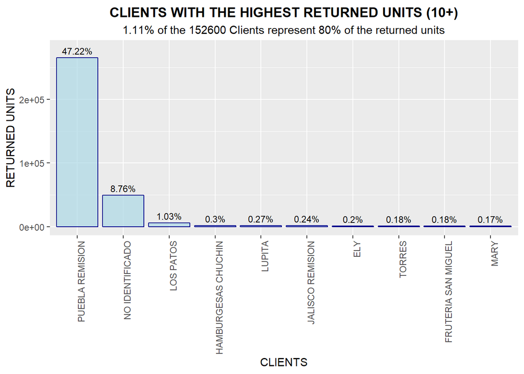

```r
ggplot(return_by_client[1:10, ] %>% filter(Cum_Perc <= 80),
       aes(x = reorder(NombreCliente, -Dev_uni_proxima), y = Dev_uni_proxima)) +
  geom_col(fill = 'lightblue', color = 'darkblue', alpha = 0.7) +
  geom_text(aes(label = paste(Perc, '%', sep = '')), vjust = -0.5, size = 3) +
  ggtitle('CLIENTS WITH THE HIGHEST RETURNED UNITS (10+)') +
  xlab('CLIENTS') +
  ylab('RETURNED UNITS') +
  ylim(0, max(return_by_client$Dev_uni_proxima) * 1.05) +
  labs(subtitle = paste(
    round(nrow(return_by_client %>% filter(Cum_Perc <= 80)) / nrow(return_by_client) * 100, 2),
    "% of the ",
    nrow(return_by_client),
    " Clients represent ",
    max(return_by_client %>% filter(Cum_Perc <= 80) %>% select(Cum_Perc)),
    "% of the returned units", sep = '')) +
  theme(plot.title = element_text(hjust = 0.5, vjust = 0.5, face = 'bold'),
        axis.text.x = element_text(angle = 90, hjust = 1),
        plot.subtitle = element_text(hjust = 0.5, vjust = 0.5))
```

```r
paste(return_by_client[10, 'Cum_Perc'], '%', sep='')
```

```
## [1] "58.55%"
```

*The top 10 represent 58.55% of the total of the returned units*

COST OF RETURN

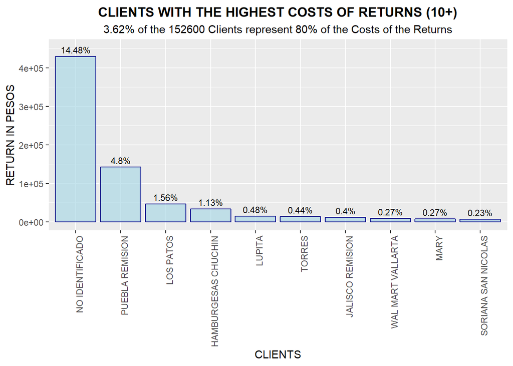

```r
ggplot(cost_by_client[1:10, ] %>% filter(Cum_Perc <= 80),
       aes(x = reorder(NombreCliente, -Dev_proxima), y = Dev_proxima)) +
  geom_col(fill = 'lightblue', color = 'darkblue', alpha = 0.7) +
  geom_text(aes(label = paste(Perc, '%', sep = '')), vjust = -0.5, size = 3) +
  ggtitle('CLIENTS WITH THE HIGHEST COSTS OF RETURNS (10+)') +
  xlab('CLIENTS') +
  ylab('RETURN IN PESOS') +
  ylim(0, max(cost_by_client$Dev_proxima) * 1.05) +
  labs(subtitle = paste(
    round(nrow(cost_by_client %>% filter(Cum_Perc <= 80)) / nrow(cost_by_client) * 100, 2),
    "% of the ",
    nrow(cost_by_client),
    " Clients represent ",
    max(cost_by_client %>% filter(Cum_Perc <= 80) %>% select(Cum_Perc)),
    "% of the Costs of the Returns", sep = '')) +
  theme(plot.title = element_text(hjust = 0.5, vjust = 0.5, face = 'bold'),
        axis.text.x = element_text(angle = 90, hjust = 1),
        plot.subtitle = element_text(hjust = 0.5, vjust = 0.5))
```

```r
paste(cost_by_client[10, 'Cum_Perc'], '%', sep='')
```

```
## [1] "24.07%"
```

*The top 10 represent 24.07% of the total of the costs with return*

List of clients

```r
list_clients <- as.vector(unlist(return_by_client %>% filter(Cum_Perc <= 80) %>% select(NombreCliente)))
```

## Functions to calculate the demand

Before define the method that will be used to predict the demand, it was suggested to test if the data set is able to be handle by a linear regression. To be able, it’s important that there are multiple occurrences of combined variables (Product, Town, NombreCliente) to train the model and then make the predictions. To guarantee a fast and efficient return, it will be considered the lists of products, town and client, compiled throughout previous analysis: **list_products:** list of products which represent 80% of the total of returned units **list_towns:** list of towns which represent 80% of the total of returned units from the list_products **list_clients:** list of towns which represent 80% of the total of returned units from the list_towns

Filtering the demands by List_products, List_towns and List_clients

```r
train_set_result <- train_set %>% filter(Product %in% list_products & Town %in% list_towns & NombreCliente %in% list_clients)
```

Checking the occurrences of combined variables

```r
combined_variables <- table(data.frame(train_set_result %>% mutate(features = paste(Product, Town, NombreCliente)))[, 'features'])
combined_variables <- data.frame(combined_variables)
colnames(combined_variables) <- c('Variables', 'Frequency')
sum(combined_variables %>% filter(Frequency == 1) %>% select(Frequency))
```

```
## [1] 248323
```

**Since the number of unique occurrences are too high, it’s being considered not appropriate to address the dataset through a linear regression**

```r
paste(round((sum(train_set_result$Dev_uni_proxima) / sum(train_set$Dev_uni_proxima)) * 100, 2), '%', sep='')
```

[1] “51.13%”

```r
train_set_result <- train_set_result[, c(2, 4, 6, 7, 10:14)]
kable(head(train_set_result))
```

| Town | NombreCliente | Product | Semana | Venta_uni_hoy | Venta_hoy | Dev_uni_proxima | Dev_proxima | Demanda_uni_equil |
| --- | --- | --- | --- | --- | --- | --- | --- | --- |
| 2029 AG.IZTAPALAPA 2 | WAL MART TLALPAN | Colchones BIM 130g 6p | 6 | 36 | 242.64 | 3 | 20.22 | 33 |
| 2029 AG.IZTAPALAPA 2 | WAL MART TLALPAN | Conchas Vainilla BIM 120g 2p | 5 | 21 | 220.08 | 0 | 0.00 | 21 |
| 2029 AG.IZTAPALAPA 2 | WAL MART TLALPAN | Pan Integral BIM 680g | 9 | 671 | 14594.25 | 9 | 195.75 | 662 |
| 2029 AG.IZTAPALAPA 2 | WAL MART TLALPAN | Mantecadas Vainilla BIM 125g 4p | 6 | 48 | 395.04 | 24 | 197.52 | 24 |
| 2029 AG.IZTAPALAPA 2 | WAL MART TLALPAN | Tostada Ondulada Tubo MR 360g 30p | 8 | 288 | 4265.28 | 0 | 0.00 | 288 |
| 2029 AG.IZTAPALAPA 2 | WAL MART TLALPAN | Pan Multigrano BIM 540g | 6 | 150 | 3145.50 | 5 | 104.85 | 145 |

**Since the Dev_uni_proxima has to do to the returned units per week, it’s important to focus on the Town and Client. So it’s recommended to reduce the mean of returns calculated by week as in the function**

This function returns the combination of Product, Town and Client per week, ordered by the most returned products from set which most impacts in about 51% of the returns.

By this function, it’s possible to adjust the combined variables with efficiency

```r
suggested_demand <- function(){
  result <- distinct(train_set_result %>%
                         group_by(Product, Town, NombreCliente, Semana) %>%
                         mutate(
                           Return_mean = mean(Dev_uni_proxima),
                           Demand_min = min(Demanda_uni_equil),
                           Demand_max = max(Demanda_uni_equil),
                           Demand_mean = mean(Demanda_uni_equil)
                         ), Town, NombreCliente, Semana, .keep_all = T)
  result <- result[, c(1:4, 10:13)]
  kable(head(result[order(-result$Return_mean), ], 50), caption = '50 first results')
  }
suggested_demand()
```

50 first results

| Town | NombreCliente | Product | Semana | Return_mean | Demand_min | Demand_max | Demand_mean |
| --- | --- | --- | --- | --- | --- | --- | --- |
| 2088 AG. CEYLAN | PUEBLA REMISION | Paletina Cafe NES NES | 9 | 250000.0000 | 0 | 0 | 0 |
| 2059 QUERETARO BALVANERA | LOS PATOS | Cuernito Jamon Queso LT LON 80g | 5 | 5795.0000 | 0 | 0 | 0 |
| 2355 JALAPA I | HAMBURGESAS CHUCHIN | Pan Blanco BIM 640g | 8 | 1686.0000 | 0 | 0 | 0 |
| 2034 ACAPULCO COSTERA | ELY | Polvoroncitos Panera TR 25g 40p | 7 | 1000.0000 | 0 | 0 | 0 |
| 2277 ZACATECAS BIMBO | FRUTERIA SAN MIGUEL | Nito BIM 62g 1p | 8 | 985.0000 | 0 | 0 | 0 |
| 2293 GRANJAS MARINELA | TORRES | Medias Noches BIM 340g 8p | 4 | 854.0000 | 0 | 0 | 0 |
| 2398 SAN CRISTOBAL | SINALOA | Triki Intenso MLA 80g | 3 | 750.0000 | 0 | 0 | 0 |
| 2059 Queretaro Balvanera | VAZQUEZ | Nito BIM 62g 1p | 8 | 530.0000 | 0 | 0 | 0 |
| 2258 COLIMA BIMBO | RAMSES ORLANDO MORAN RIOS | Cuernito Jamon Queso LT LON 80g | 9 | 500.0000 | 0 | 0 | 0 |
| 2041 AG. TULTITLAN | ARATH BURGUER | Barritas Pina MLA 67g | 7 | 400.0000 | 0 | 0 | 0 |
| 2269 PUERTO VALLARTA BIMBO | BILIULFA PERALTA GUTIERREZ | Nito BIM 62g 1p | 8 | 397.0000 | 0 | 0 | 0 |
| 2044 CUERNAVACA BUENAVISTA | MORELOS REMISION | Coca Cola Lata CC 355ml | 8 | 361.0000 | 333 | 333 | 333 |
| 2417 ZACATLAN | NO IDENTIFICADO | Barritas Fresa MLA 67g | 9 | 359.0000 | 0 | 0 | 0 |
| 2294 GUADALAJARA | JUAN ALVARADO CAMPOS | Nito BIM 62g 1p | 4 | 324.0000 | 0 | 0 | 0 |
| 2278 ZAPOPAN BIMBO | JOSEFINA FLORES HARO | Bolsa Mini Rocko MLA 13g 40p | 5 | 320.0000 | 0 | 0 | 0 |
| 2161 IRAPUATO GUADALUPE | PUEBLA REMISION | Doraditas TR 110g | 9 | 301.0000 | 0 | 0 | 0 |
| 2269 PUERTO VALLARTA BIMBO | CHURCHS CHICKEN PTO VALLARTA | Medias Noches BIM 340g 8p | 3 | 284.0000 | 0 | 0 | 0 |
| 2384 CIUDAD DEL CARMEN | CHEDRAUI CD DEL CARMEN 2 | Barritas Fresa MLA 67g | 5 | 282.0000 | 0 | 0 | 0 |
| 2390 INDUSTRIAL | YEN MAR | Bolsa Mini Rocko MLA 13g 40p | 5 | 280.0000 | 0 | 0 | 0 |
| 2260 GONZALEZ GALLO | JALISCO REMISION | Barritas Fresa MLA 67g | 4 | 269.0000 | 0 | 0 | 0 |
| 2158 CUERNAVACA CIVAC | LA CREPA | Barritas Fresa MLA 67g | 9 | 255.0000 | 0 | 0 | 0 |
| 2056 PUEBLA NORTE MARINELA | NO IDENTIFICADO | Canelitas MLA 90g | 9 | 251.3333 | 0 | 90 | 30 |
| 2057 PUEBLA SUR MARINELA | JUANITA | Barritas Fresa MLA 67g | 4 | 250.0000 | 0 | 0 | 0 |
| 2407 TEPEACA | ABARROTES LA UNION | Bolsa Mini Rocko MLA 13g 40p | 7 | 240.0000 | 0 | 0 | 0 |
| 2034 ACAPULCO COSTERA | COMERCIAL MEXICANA ACAPULCO VISTA ALEGRE | Doraditas TR 110g | 3 | 230.0000 | 0 | 0 | 0 |
| 2034 ACAPULCO COSTERA | BRENDA | Principe MLA 106g 10p | 5 | 220.0000 | 0 | 0 | 0 |
| 2407 TEPEACA | NO IDENTIFICADO | Canelitas MLA 90g | 7 | 219.0000 | 0 | 0 | 0 |
| 2070 AG. XOCHIMILCO 1 | LA PASADITA | Donas Azucar BIM 105g 4p | 7 | 210.0000 | 0 | 0 | 0 |
| 2365 PUEBLA SUR BIMBO | ANTOJITOS LOPEZ | Barritas Fresa MLA 67g | 6 | 200.0000 | 0 | 0 | 0 |
| 2392 MERIDA NORTE | PUEBLA REMISION | Kiyakis BAR 50g 25p | 9 | 200.0000 | 7 | 7 | 7 |
| 2468 MATAMOROS BIMBO | PUEBLA REMISION | Coca Cola Lata CC 355ml | 6 | 194.0000 | 528 | 528 | 528 |
| 2041 AG. TULTITLAN | LETY | Choco Roles MLA 80g 2p | 5 | 192.0000 | 0 | 0 | 0 |
| 2188 MARAVATIO | ABARROTES LA PEQUEA | Barritas Fresa MLA 67g | 3 | 181.0000 | 0 | 0 | 0 |
| 2161 IRAPUATO GUADALUPE | MARISCOS LA LAGUNA DE CHAIREL | Medias Noches BIM 340g 8p | 9 | 180.0000 | 0 | 0 | 0 |
| 2059 QUERETARO BALVANERA | FRUTERIA LETY | Choco Roles MLA 80g 2p | 7 | 180.0000 | 0 | 0 | 0 |
| 2396 RUIZ CORTINEZ | EL BOULEVARD | Nito BIM 62g 1p | 7 | 180.0000 | 0 | 0 | 0 |
| 2182 ZITACUARO | FRANCISCO PANTOJA SOLORZANO | Barritas Fresa MLA 67g | 6 | 169.0000 | 0 | 0 | 0 |
| 2390 INDUSTRIAL | CAJILLERO MERCADO PINOSUAREZ | Tostado BIM 210g | 6 | 161.0000 | 0 | 0 | 0 |
| 2517 SENDERO AUTOSERVICIO | SORIANA SAN NICOLAS | Pan Blanco BIM 680g | 3 | 161.0000 | 180 | 180 | 180 |
| 2251 AGUASCALIENTES NORTE | NESTOR LOPEZ VITAL | Bolsa Mini Rocko MLA 13g 40p | 4 | 160.0000 | 0 | 0 | 0 |
| 2251 AGUASCALIENTES NORTE | NOE FLORES DIAZ DE LEON | Bolsa Mini Rocko MLA 13g 40p | 8 | 160.0000 | 0 | 0 | 0 |
| 2382 CARDENAS | CASA PEREZ | Polvoroncitos Panera TR 25g 40p | 6 | 160.0000 | 0 | 0 | 0 |
| 2368 TAMPICO BIMBO | HOTEL MEDA | Pan Blanco BIM 640g | 8 | 160.0000 | 0 | 0 | 0 |
| 2416 PACHUCA II | MENESES | Tostado BIM 210g | 7 | 152.0000 | 0 | 0 | 0 |
| 2386 COATZACOALCOS MLA. | SUPER E SA DE CV | Tostado BIM 210g | 3 | 149.0000 | 0 | 0 | 0 |
| 2260 GONZALEZ GALLO | JALISCO REMISION | Coca Cola Lata CC 355ml | 8 | 148.0000 | 649 | 649 | 649 |
| 2505 TORREON | LIQUIDACION JOSE ISAIAS SALAS | Canelitas MLA 90g | 6 | 147.0000 | 0 | 0 | 0 |
| 2554 CD. OBREGON | PUEBLA REMISION | Barritas Pina MLA 67g | 8 | 147.0000 | 0 | 0 | 0 |
| 2048 AG. IXTAPALUCA 1 | LA JOVEN MICHOACANA | Canelitas MLA 90g | 7 | 145.0000 | 0 | 0 | 0 |
| 2485 CHIHUAHUA MARINELA | PUEBLA REMISION | Coca Cola Lata CC 355ml | 8 | 145.0000 | 401 | 401 | 401 |

This function lists the combination of Town and Client per week, ordered by the highest number of returns of the Product which was choosed by the user.

```r
return_demand_product <- function(prod){
  result <- train_set %>% filter(Product == prod)
  result_2 <- distinct(result %>%
                         group_by(Town, NombreCliente, Semana) %>%
                         mutate(
                           Return_mean = mean(Dev_uni_proxima),
                           Demand_min = min(Demanda_uni_equil),
                           Demand_max = max(Demanda_uni_equil),
                           Demand_mean = mean(Demanda_uni_equil)
                         ), Town, NombreCliente, Semana, .keep_all = T)
  result_2 <- result_2[, c(2, 4, 6, 7, 15:18)]
  kable(head(result_2[order(-result_2$Return_mean), ], 50), caption = '50 first results')
}
```

**Example of use for the 2nd more returned product**

```r
return_demand_product('Nito BIM 62g 1p')
```

50 first results

| Town | NombreCliente | Product | Semana | Return_mean | Demand_min | Demand_max | Demand_mean |
| --- | --- | --- | --- | --- | --- | --- | --- |
| 2277 ZACATECAS BIMBO | FRUTERIA SAN MIGUEL | Nito BIM 62g 1p | 8 | 985 | 0 | 0 | 0.0 |
| 2059 Queretaro Balvanera | VAZQUEZ | Nito BIM 62g 1p | 8 | 530 | 0 | 0 | 0.0 |
| 2269 PUERTO VALLARTA BIMBO | BILIULFA PERALTA GUTIERREZ | Nito BIM 62g 1p | 8 | 397 | 0 | 0 | 0.0 |
| 2294 GUADALAJARA | JUAN ALVARADO CAMPOS | Nito BIM 62g 1p | 4 | 324 | 0 | 0 | 0.0 |
| 2396 RUIZ CORTINEZ | EL BOULEVARD | Nito BIM 62g 1p | 7 | 180 | 0 | 0 | 0.0 |
| 2466 LINARES | OXXO INFONAVIT MONTEMORELOS | Nito BIM 62g 1p | 6 | 144 | 0 | 0 | 0.0 |
| 2296 IRAPUATO SAN MIGUELITO | PIKIN | Nito BIM 62g 1p | 7 | 113 | 7 | 7 | 7.0 |
| 2272 SAN LUIS REY | FRUTY FIESTA | Nito BIM 62g 1p | 7 | 112 | 0 | 0 | 0.0 |
| 2251 AGUASCALIENTES NORTE | FRASUTO | Nito BIM 62g 1p | 7 | 90 | 0 | 0 | 0.0 |
| 2515 CAVAZOS | ROMULO GONZALEZ RAMIREZ | Nito BIM 62g 1p | 5 | 90 | 0 | 0 | 0.0 |
| 2314 SAN LUCAS | SORIANA BRISAS DEL PACIFICO | Nito BIM 62g 1p | 9 | 88 | 34 | 34 | 34.0 |
| 2477 SALTILLO BIMBO | BODEGA OTILIO GONZALEZ | Nito BIM 62g 1p | 9 | 88 | 0 | 0 | 0.0 |
| 2255 CD GUZMAN | ALEJANDRA FLORES ROSAS | Nito BIM 62g 1p | 6 | 84 | 0 | 0 | 0.0 |
| 2554 CD. OBREGON | OXXO INDUSTRIALES | Nito BIM 62g 1p | 8 | 80 | 0 | 0 | 0.0 |
| 2412 APAN | LA BUGAMBILIA | Nito BIM 62g 1p | 5 | 80 | 0 | 0 | 0.0 |
| 2161 IRAPUATO GUADALUPE | BETO | Nito BIM 62g 1p | 4 | 80 | 49 | 49 | 49.0 |
| 2462 JUAREZ BIMBO | SMART ECOTIENDA | Nito BIM 62g 1p | 5 | 77 | 31 | 31 | 31.0 |
| 2088 AG. CEYLAN | LUCERO | Nito BIM 62g 1p | 7 | 73 | 0 | 0 | 0.0 |
| 2554 CD. OBREGON | BODEGA BURLOUG CD OBREGON | Nito BIM 62g 1p | 8 | 73 | 0 | 0 | 0.0 |
| 2462 JUAREZ BIMBO | SMART LIBRAMIENTO | Nito BIM 62g 1p | 9 | 73 | 35 | 35 | 35.0 |
| 2567 PUERTO PEÑASCO | MINI SUPER REFORMA | Nito BIM 62g 1p | 6 | 72 | 0 | 0 | 0.0 |
| 2002 AG. AZCAPOTZALCO | LA ESPERANZA | Nito BIM 62g 1p | 9 | 71 | 0 | 0 | 0.0 |
| 2467 LINCOLN | OXXO PARQUE PONIENTE | Nito BIM 62g 1p | 6 | 71 | 37 | 37 | 37.0 |
| 2466 LINARES | OXXO CAPILLAS | Nito BIM 62g 1p | 6 | 70 | 2 | 2 | 2.0 |
| 2161 IRAPUATO GUADALUPE | MANUEL CISNEROS VILLALPANDO | Nito BIM 62g 1p | 8 | 65 | 7 | 7 | 7.0 |
| 2396 RUIZ CORTINEZ | OXXO EDMAGRA | Nito BIM 62g 1p | 6 | 65 | 55 | 55 | 55.0 |
| 2555 ENSENADA II | OXXO NACIONALISTA | Nito BIM 62g 1p | 7 | 64 | 0 | 0 | 0.0 |
| 2252 AGUASCALIENTES SIGLO XXI | SUPER FARMACIA DURAN | Nito BIM 62g 1p | 8 | 62 | 10 | 10 | 10.0 |
| 2376 CONVENIENCIA VERACRUZ SUR | BETY | Nito BIM 62g 1p | 5 | 61 | 0 | 0 | 0.0 |
| 2313 SAN JOSE DEL CABO | HIPER SORIANA SAN JOSE VIEJO | Nito BIM 62g 1p | 4 | 61 | 17 | 17 | 17.0 |
| 2321 ZACATECAS MARINELA | EL MIRADOR | Nito BIM 62g 1p | 6 | 60 | 0 | 0 | 0.0 |
| 2309 NORTE | JOSE ALFREDO GUERRA GARCIA | Nito BIM 62g 1p | 3 | 57 | 0 | 0 | 0.0 |
| 2367 SAN MARTIN T. | DON PEPE | Nito BIM 62g 1p | 5 | 56 | 39 | 39 | 39.0 |
| 2031 AG. PANTITLAN | EL GUACHE | Nito BIM 62g 1p | 7 | 56 | 0 | 0 | 0.0 |
| 2276 WONDER LA RAZA | JOSE ALFREDO MILAN RODRIGUEZ | Nito BIM 62g 1p | 7 | 55 | 0 | 0 | 0.0 |
| 2517 SENDERO AUTOSERVICIO | HEB VALLE ORIENTE | Nito BIM 62g 1p | 7 | 55 | 0 | 0 | 0.0 |
| 2255 CD GUZMAN | SOCORRO CORONA BENAVIDES | Nito BIM 62g 1p | 5 | 54 | 0 | 0 | 0.0 |
| 2328 SANTIAGO IXCUINTLA | MINI SUPER KARINA | Nito BIM 62g 1p | 8 | 54 | 0 | 0 | 0.0 |
| 2504 TAMPICO MARINELA | ARTELI HIDALGO | Nito BIM 62g 1p | 9 | 53 | 0 | 0 | 0.0 |
| 2152 ALTAMIRANO_BM | ABARROTES PALACIOS | Nito BIM 62g 1p | 6 | 52 | 79 | 79 | 79.0 |
| 2466 LINARES | OXXO DR CARLOS GARCIA | Nito BIM 62g 1p | 3 | 51 | 0 | 0 | 0.0 |
| 2255 CD GUZMAN | ABEL MENDOZA CONTRERAS | Nito BIM 62g 1p | 7 | 50 | 66 | 66 | 66.0 |
| 2480 VICTORIA BIMBO | HIPER SORIANA LAS PALMAS | Nito BIM 62g 1p | 4 | 50 | 0 | 0 | 0.0 |
| 2407 TEPEACA | VITORIO | Nito BIM 62g 1p | 6 | 50 | 0 | 0 | 0.0 |
| 2159 CHILPANCINGO | NATIVIDAD | Nito BIM 62g 1p | 4 | 50 | 0 | 11 | 5.5 |
| 2048 AG. IXTAPALUCA 1 | OXXO SAN BUENAVENTURA | Nito BIM 62g 1p | 6 | 49 | 0 | 0 | 0.0 |
| 2273 SAN PEDRO | TERESITA HERNANDEZ HERNANDEZ | Nito BIM 62g 1p | 8 | 48 | 0 | 0 | 0.0 |
| 2259 FRESNILLO BIMBO | ABARROTES ALVARADO | Nito BIM 62g 1p | 8 | 48 | 72 | 72 | 72.0 |
| 2269 PUERTO VALLARTA BIMBO | SORIANA PLAYA DE ORO | Nito BIM 62g 1p | 3 | 48 | 0 | 0 | 0.0 |
| 2165 LEON SAN JUAN BOSCO | MILAGROS DE MONSERRAT | Nito BIM 62g 1p | 4 | 48 | 0 | 0 | 0.0 |

## Final notes

It’s been presented variables which can be used to ponder the demand:  
**Demand_min:** minimum of demand per week  
**Demand_max:** maximum of demand per week  
**Demand_mean:** mean of demand per week

With these numbers, it can be limit the maximum number of products of a specific variable combination, and ponder if the orders are reasonable. With new datas, this script can be run again and as the returns descrease, new combined features will be shown.